# Cx4073 : Assignment 1

GUVVALA SANJUSHA

U1521432J

### Task 1 : Perform a detailed exploratory data analysis and regression model building based on assign1_EnergyData.csv

Library Packages used

```r
library(DataExplorer)
library(corrplot)
library("PerformanceAnalytics")
```

Step 1 : Import the CSV data file `assign1_EnergyData.csv` for analysis, and quickly check the structure of the data.

```r
energydata <- read.csv("assign1_EnergyData.csv", header = TRUE)
```

Step 2 : Perform some basic Explorations

2a : dimension of the dataset

```r
dim(energydata)
```

```
## [1] 700  10
```

2b : labels of the columns/variables

```r
names(energydata)
```

```
##  [1] "Compactness" "SurfaceArea" "WallArea"    "RoofArea"    "Height"
##  [6] "Orientation" "GlazingArea" "GAreaDist"   "HeatingLoad" "CoolingLoad"
```

2c : structure of the dataset

```r
str(energydata)
```

```
## 'data.frame':    700 obs. of  10 variables:
##  $ Compactness: num  0.74 0.9 0.79 0.69 0.82 0.98 0.69 0.62 0.62 0.66 ...
##  $ SurfaceArea: num  686 564 637 735 612 ...
##  $ WallArea   : num  245 318 343 294 318 ...
##  $ RoofArea   : num  220 122 147 220 147 ...
##  $ Height     : num  3.5 7 7 3.5 7 7 3.5 3.5 3.5 3.5 ...
##  $ Orientation: int  2 5 3 5 5 4 2 4 3 3 ...
##  $ GlazingArea: num  0.4 0.1 0 0.4 0.1 0.25 0.25 0.1 0.1 0.25 ...
##  $ GAreaDist  : int  3 4 0 3 5 5 3 5 2 1 ...
##  $ HeatingLoad: num  14 29.8 29.9 14.1 23.9 ...
##  $ CoolingLoad: num  16.1 29.9 31.3 17 27.7 ...
```

2d : Observing first few rows of the data

```r
head(energydata)
```

```
##   Compactness SurfaceArea WallArea RoofArea Height Orientation GlazingArea
## 1        0.74       686.0    245.0   220.50    3.5           2        0.40
## 2        0.90       563.5    318.5   122.50    7.0           5        0.10
## 3        0.79       637.0    343.0   147.00    7.0           3        0.00
## 4        0.69       735.0    294.0   220.50    3.5           5        0.40
## 5        0.82       612.5    318.5   147.00    7.0           5        0.10
## 6        0.98       514.5    294.0   110.25    7.0           4        0.25
##   GAreaDist HeatingLoad CoolingLoad
## 1         3       13.97       16.08
## 2         4       29.79       29.92
## 3         0       29.90       31.27
## 4         3       14.08       17.02
## 5         5       23.86       27.69
## 6         5       28.15       30.00
```

2e : Observing last few rows of the data

```r
tail(energydata)
```

```
##     Compactness SurfaceArea WallArea RoofArea Height Orientation
## 695        0.62       808.5    367.5    220.5    3.5           5
## 696        0.69       735.0    294.0    220.5    3.5           4
## 697        0.62       808.5    367.5    220.5    3.5           5
## 698        0.64       784.0    343.0    220.5    3.5           2
## 699        0.86       588.0    294.0    147.0    7.0           4
## 700        0.90       563.5    318.5    122.5    7.0           3
##     GlazingArea GAreaDist HeatingLoad CoolingLoad
## 695        0.25         4       14.65       15.38
## 696        0.25         1       12.73       15.48
## 697        0.40         2       17.15       16.99
## 698        0.25         4       16.99       19.65
## 699        0.25         5       28.31       34.15
## 700        0.25         4       31.69       37.12
```

2f : Summary statistics for all variables

```r
summary(energydata)
```

```
##   Compactness      SurfaceArea       WallArea        RoofArea
##  Min.   :0.6200   Min.   :514.5   Min.   :245.0   Min.   :110.2
##  1st Qu.:0.6900   1st Qu.:612.5   1st Qu.:294.0   1st Qu.:147.0
##  Median :0.7400   Median :686.0   Median :318.5   Median :220.5
##  Mean   :0.7633   Mean   :672.4   Mean   :318.1   Mean   :177.1
##  3rd Qu.:0.8200   3rd Qu.:735.0   3rd Qu.:343.0   3rd Qu.:220.5
##  Max.   :0.9800   Max.   :808.5   Max.   :416.5   Max.   :220.5
##      Height      Orientation     GlazingArea       GAreaDist
##  Min.   :3.50   Min.   :2.000   Min.   :0.0000   Min.   :0.000
##  1st Qu.:3.50   1st Qu.:3.000   1st Qu.:0.1000   1st Qu.:2.000
##  Median :3.50   Median :3.000   Median :0.2500   Median :3.000
##  Mean   :5.24   Mean   :3.499   Mean   :0.2355   Mean   :2.807
##  3rd Qu.:7.00   3rd Qu.:4.250   3rd Qu.:0.4000   3rd Qu.:4.000
##  Max.   :7.00   Max.   :5.000   Max.   :0.4000   Max.   :5.000
##   HeatingLoad     CoolingLoad
##  Min.   : 6.01   Min.   :10.90
##  1st Qu.:13.01   1st Qu.:15.64
##  Median :18.77   Median :21.84
##  Mean   :22.22   Mean   :24.51
##  3rd Qu.:31.28   3rd Qu.:32.92
##  Max.   :43.10   Max.   :48.03
```

Step 3 : View some Exploratory Plots

3a : histograms of all individual variables

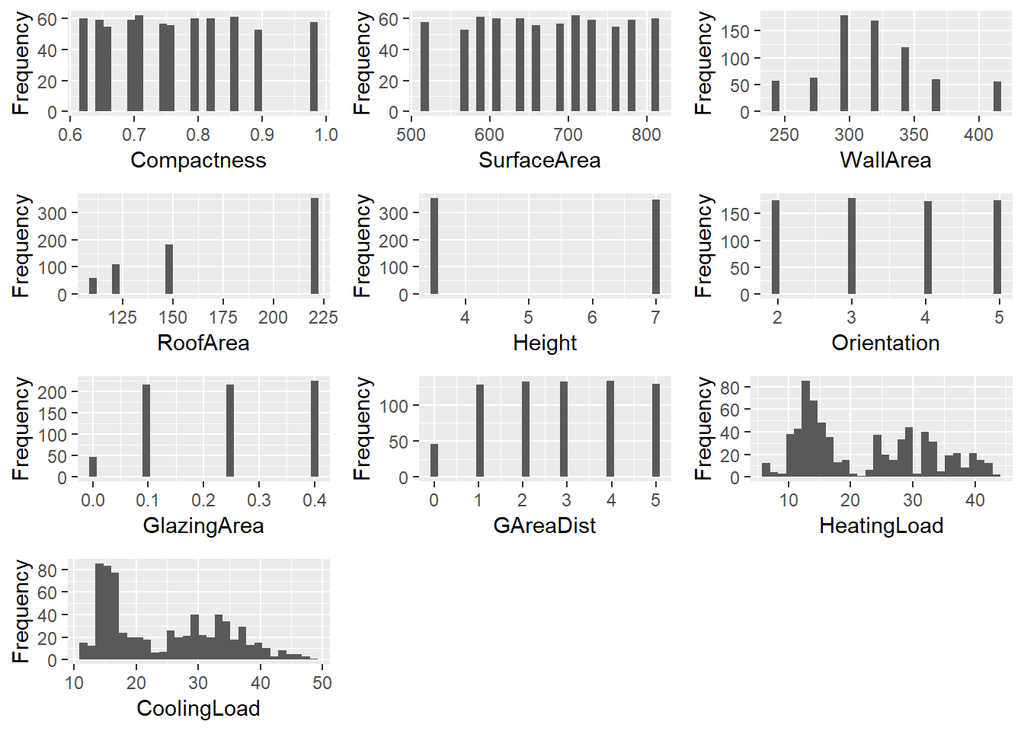

```r
plot_histogram(energydata)
```

Observations from histograms

1. Compactness, SurfaceArea The histograms of these variables shows an even distribution where all values have similar frequency ranging from 45 to 65 and the distribution is continuous as the bars are close and very far away.
2. WallArea, RoofArea, GAreaDist The distribution of these variables is skewed to the left or Negative Skew.
3. Height, Orientation, GlazingArea The histograms show very small number of intervals and distribution does not seem to be continuous due the slightly large distance gap between the intervals.
4. HeatingLoad, CoolingLoad The histograms show that HeatingLoad and CoolingLoad are quite frequent with between 10 to 20 values. The distribution is continuous due to the bars are touching in a continuity manner. And the distribution is skewed to the right or positive skew.

3b : boxplots against Heating Load

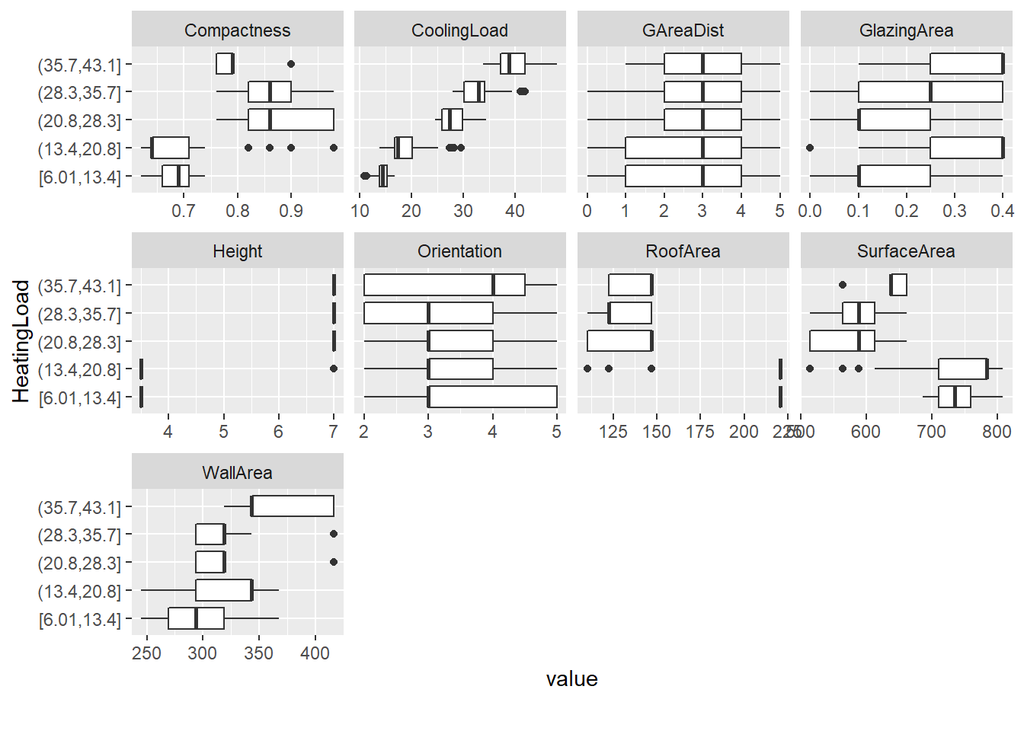

```r
plot_boxplot(energydata,by='HeatingLoad')
```

Observations from boxplots

1. Comparing HeatingLoad with Compactness, Orientation, GlazingArea, RoofArea, SurfaceArea, WallArea It seems that they have no linear relationship with HeatingLoad as the range of HeatingLoad increases the median has random values for each range and also the values are not evenly distributed.
2. Comparing HeatingLoad with GAreaDist The median remain the same for each range of HeatingLoad, hence mostly the values are distributed well.
3. Comparing HeatingLoad with Height We can observe from the boxplots that the lower ranges of Heating Load (6.01,13.4),(13.4,20.8) have the Height value of 3.5. While the higher ranges (20.8,28.3),(28.3,35.7),(35.7,43.1) have the Height value of 7. Therefore, there are only two values of Height for any record.

Step 4 : Find the correlations between variables

```r
cor(energydata)
```

```
##              Compactness  SurfaceArea    WallArea     RoofArea
## Compactness  1.000000000 -0.991809299 -0.20812361 -0.869691184
## SurfaceArea -0.991809299  1.000000000  0.20130347  0.880997750
## WallArea    -0.208123615  0.201303470  1.00000000 -0.286087266
## RoofArea    -0.869691184  0.880997750 -0.28608727  1.000000000
## Height       0.828217657 -0.858340532  0.27432148 -0.972153083
## Orientation  0.002895461 -0.002339471 -0.01373944  0.004347724
## GlazingArea -0.022618635  0.020026945 -0.00447997  0.021754799
## GAreaDist    0.017067129 -0.013939406 -0.01454338 -0.006611360
## HeatingLoad  0.613965409 -0.650383231  0.45153417 -0.854318402
## CoolingLoad  0.629535257 -0.668604808  0.42161086 -0.857690073
##                   Height  Orientation  GlazingArea    GAreaDist
## Compactness  0.828217657  0.002895461 -0.022618635  0.017067129
## SurfaceArea -0.858340532 -0.002339471  0.020026945 -0.013939406
## WallArea     0.274321482 -0.013739441 -0.004479970 -0.014543378
## RoofArea    -0.972153083  0.004347724  0.021754799 -0.006611360
## Height       1.000000000 -0.008961975 -0.013924794  0.005742054
## Orientation -0.008961975  1.000000000  0.001529999  0.022541886
## GlazingArea -0.013924794  0.001529999  1.000000000  0.236956380
## GAreaDist    0.005742054  0.022541886  0.236956380  1.000000000
## HeatingLoad  0.884971395 -0.011043954  0.263708130  0.100780744
## CoolingLoad  0.893038477  0.001686366  0.201229083  0.061463685
##             HeatingLoad  CoolingLoad
## Compactness  0.61396541  0.629535257
## SurfaceArea -0.65038323 -0.668604808
## WallArea     0.45153417  0.421610863
## RoofArea    -0.85431840 -0.857690073
## Height       0.88497140  0.893038477
## Orientation -0.01104395  0.001686366
## GlazingArea  0.26370813  0.201229083
## GAreaDist    0.10078074  0.061463685
## HeatingLoad  1.00000000  0.975695932
## CoolingLoad  0.97569593  1.000000000
```

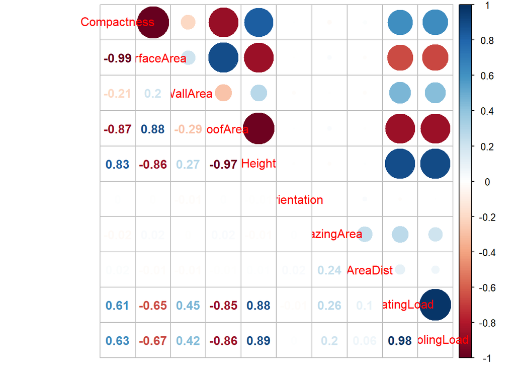

```r
corrplot.mixed(cor(energydata))
```

Step 5 : Plot 2d scatterplots of all pairs of variables

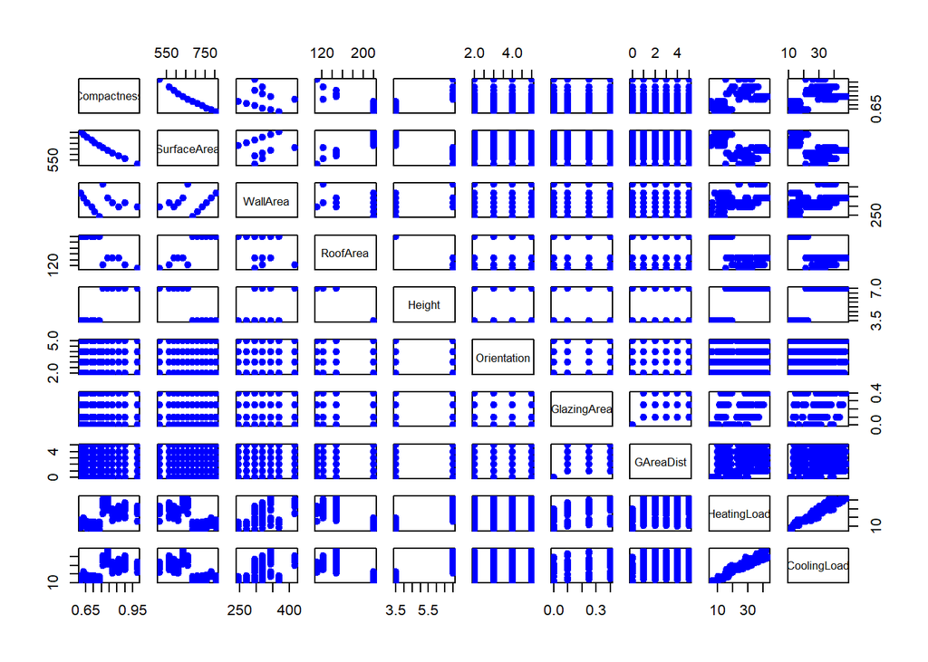

```r
energydata$Orientation<-as.numeric(energydata$Orientation)
pairs(energydata, pch = 19, col = "blue")
```

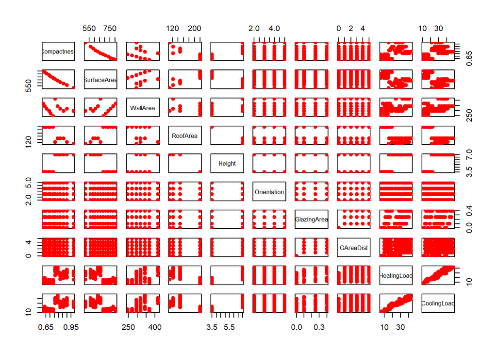

```r
pairs(energydata[,-11], pch = 19, col="red")
```

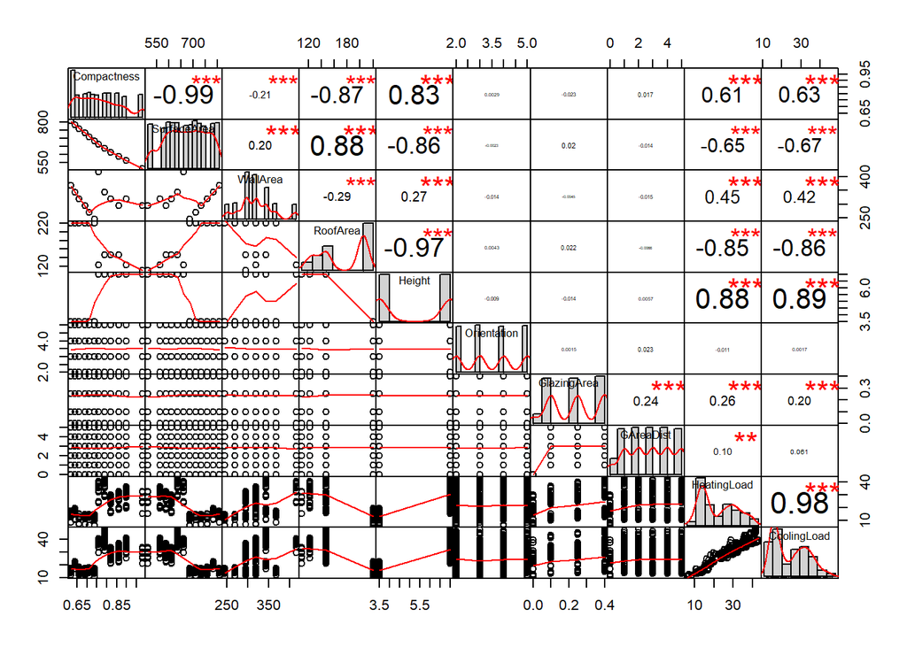

```r
chart.Correlation(energydata, histogram=TRUE, pch=19)
```

What is the intuitive inference from the plot? . A high correlation value may be the result of chance and not significant . A low correlation value may be significant, a small but still meaningful relationship

Step 6 : Perform Linear Regression on HeatingLoad

6a : fit a linear model on HeatingLoad vs all other variables Backward method consider all variables and remove variables one by one This is the first model also called the FULL MODEL As the prediction is for HeatingLoad and CoolingLoad separately, exclude CoolingLoad variable from the HeatingLoad model

```r
lmFit1 <- lm(HeatingLoad~ .-CoolingLoad, data = energydata)
```

6b : display the “summary” of the linear model

```r
summary(lmFit1)
```

```
##
## Call:
## lm(formula = HeatingLoad ~ . - CoolingLoad, data = energydata)
##
## Residuals:
##    Min     1Q Median     3Q    Max
## -9.741 -1.387 -0.009  1.429  7.801
##
## Coefficients: (1 not defined because of singularities)
##               Estimate Std. Error t value Pr(>|t|)
## (Intercept)  86.281259  20.135122   4.285 2.09e-05 ***
## Compactness -66.788908  10.895516  -6.130 1.48e-09 ***
## SurfaceArea  -0.088905   0.018075  -4.919 1.09e-06 ***
## WallArea      0.061183   0.007068   8.657  < 2e-16 ***
## RoofArea            NA         NA      NA       NA
## Height        4.180264   0.356547  11.724  < 2e-16 ***
## Orientation  -0.017580   0.100465  -0.175 0.861144
## GlazingArea  19.878076   0.860806  23.092  < 2e-16 ***
## GAreaDist     0.250531   0.074553   3.360 0.000821 ***
## ---
## Signif. codes:  0 '***' 0.001 '**' 0.01 '*' 0.05 '.' 0.1 ' ' 1
##
## Residual standard error: 2.966 on 692 degrees of freedom
## Multiple R-squared:  0.9137, Adjusted R-squared:  0.9129
## F-statistic:  1047 on 7 and 692 DF,  p-value: < 2.2e-16
```

6c : what is the residual standard error of the model? Residual standard error: 2.966 on 692 degrees of freedom

6d : what is the Multiple R-squared of the model? Multiple R-squared: 0.9137

6e : what is the Adjusted R-squared of the model? Adjusted R-squared: 0.9129

6f : why is Adjusted R-Squared less than Multiple R-squared? Because Adjusted R-squared adjusts Multiple R-squared with the number of parameters used in the model, as follows: Adj R^2 = 1 - (1- R^2)*(n-1)/(n-p-1)

6g : which variable to remove from linear model? why? This line “Coefficients: (1 not defined because of singularities)” indicates that R can’t estimate all the parameters because the predictor variables are not all linearly independent. As observed from the p values of all variables, the variable RoofArea p value is NA, this means that the variable is linearly dependent on the other 8 variables. R’s lm function (and all properly constructed R regression functions as well) will automatically exclude linearly dependent variables . Therefore, remove RoofArea variables first to build the model for HeatingLoad

Step 7 : Build an Updated Model removing Variables

```r
lmFit2 <- update(lmFit1, ~ . - RoofArea, data = energydata)
```

7b : display the “summary” of the updated linear model

```r
summary(lmFit2)
```

```
##
## Call:
## lm(formula = HeatingLoad ~ Compactness + SurfaceArea + WallArea +
##     Height + Orientation + GlazingArea + GAreaDist, data = energydata)
##
## Residuals:
##    Min     1Q Median     3Q    Max
## -9.741 -1.387 -0.009  1.429  7.801
##
## Coefficients:
##               Estimate Std. Error t value Pr(>|t|)
## (Intercept)  86.281259  20.135122   4.285 2.09e-05 ***
## Compactness -66.788908  10.895516  -6.130 1.48e-09 ***
## SurfaceArea  -0.088905   0.018075  -4.919 1.09e-06 ***
## WallArea      0.061183   0.007068   8.657  < 2e-16 ***
## Height        4.180264   0.356547  11.724  < 2e-16 ***
## Orientation  -0.017580   0.100465  -0.175 0.861144
## GlazingArea  19.878076   0.860806  23.092  < 2e-16 ***
## GAreaDist     0.250531   0.074553   3.360 0.000821 ***
## ---
## Signif. codes:  0 '***' 0.001 '**' 0.01 '*' 0.05 '.' 0.1 ' ' 1
##
## Residual standard error: 2.966 on 692 degrees of freedom
## Multiple R-squared:  0.9137, Adjusted R-squared:  0.9129
## F-statistic:  1047 on 7 and 692 DF,  p-value: < 2.2e-16
```

7c : did the Multiple R-squared improve? why? No. It can’t improve as we removed a variable. Multiple R-squared: 0.9137

7d : did the Adjusted R-squared improve? why? No. Because we removed a variable that will have no significance in the model. Adjusted R-squared: 0.9129

Now, consider the least significant variable to remove 7e : which variable is least significant? why? It seems that Orientation is least significant (p-value = 0.861144)

Step 8 : Build an Updated Model removing Variables

8a : fit a linear model with all remaining variables but the ones with the least significance in the previous model

```r
lmFit3 <- update(lmFit2, ~ . - Orientation, data = energydata)
```

8b : display the “summary” of the updated linear model

```r
summary(lmFit3)
```

```
##
## Call:
## lm(formula = HeatingLoad ~ Compactness + SurfaceArea + WallArea +
##     Height + GlazingArea + GAreaDist, data = energydata)
##
## Residuals:
##     Min      1Q  Median      3Q     Max
## -9.7685 -1.3774 -0.0098  1.4316  7.8088
##
## Coefficients:
##               Estimate Std. Error t value Pr(>|t|)
## (Intercept)  86.161566  20.109420   4.285 2.09e-05 ***
## Compactness -66.763950  10.886960  -6.132 1.45e-09 ***
## SurfaceArea  -0.088847   0.018060  -4.920 1.08e-06 ***
## WallArea      0.061162   0.007062   8.661  < 2e-16 ***
## Height        4.181757   0.356195  11.740  < 2e-16 ***
## GlazingArea  19.878593   0.860199  23.109  < 2e-16 ***
## GAreaDist     0.250233   0.074481   3.360 0.000823 ***
## ---
## Signif. codes:  0 '***' 0.001 '**' 0.01 '*' 0.05 '.' 0.1 ' ' 1
##
## Residual standard error: 2.964 on 693 degrees of freedom
## Multiple R-squared:  0.9137, Adjusted R-squared:  0.913
## F-statistic:  1223 on 6 and 693 DF,  p-value: < 2.2e-16
```

8c : did the Multiple R-squared improve? why? No. It can’t improve as we removed a variable. Multiple R-squared: 0.9137

8d : did the Adjusted R-squared improve? why? Yes. Because we removed a less significant variable. Adjusted R-squared: 0.913

8e : which variable is least significant? why? It seems that GAreaDist is least significant (p-value = 0.000823)

Step 9 : Build an Updated Model removing Variables

9a : fit a linear model with all the remaining variables but the ones with the least significance in the previous model

```r
lmFit4 <- update(lmFit3, ~ . - GAreaDist, data = energydata)
```

9b : display the “summary” of the updated linear model

```r
summary(lmFit4)
```

```
##
## Call:
## lm(formula = HeatingLoad ~ Compactness + SurfaceArea + WallArea +
##     Height + GlazingArea, data = energydata)
##
## Residuals:
##      Min       1Q   Median       3Q      Max
## -10.3058  -1.4068   0.0165   1.3730   7.4574
##
## Coefficients:
##               Estimate Std. Error t value Pr(>|t|)
## (Intercept)  84.833263  20.254001   4.188 3.17e-05 ***
## Compactness -65.628229  10.962065  -5.987 3.43e-09 ***
## SurfaceArea  -0.087310   0.018187  -4.801 1.94e-06 ***
## WallArea      0.060835   0.007113   8.553  < 2e-16 ***
## Height        4.195610   0.358802  11.693  < 2e-16 ***
## GlazingArea  20.565365   0.841727  24.432  < 2e-16 ***
## ---
## Signif. codes:  0 '***' 0.001 '**' 0.01 '*' 0.05 '.' 0.1 ' ' 1
##
## Residual standard error: 2.986 on 694 degrees of freedom
## Multiple R-squared:  0.9123, Adjusted R-squared:  0.9117
## F-statistic:  1445 on 5 and 694 DF,  p-value: < 2.2e-16
```

9c : did the Multiple R-squared improve? why? No. It can’t improve as we removed a variable. Multiple R-squared: 0.9123

9d : did the Adjusted R-squared improve? why? No. It slightly decreased. Adjusted R-squared: 0.9117 But we did not lose by much, and by removing GAreaDist, we got all the remaining variables highly significant, and the F-statistic improved compared to the previous model.

Step 10 : Judge the overall status of the Model

10a : more variables should be removed? why? No, it seems that all remaining variables are highly significant.

Step 11 : Check for Non-linear Relations with Variables

11a : plot HeatingLoad vs all the remaining variables

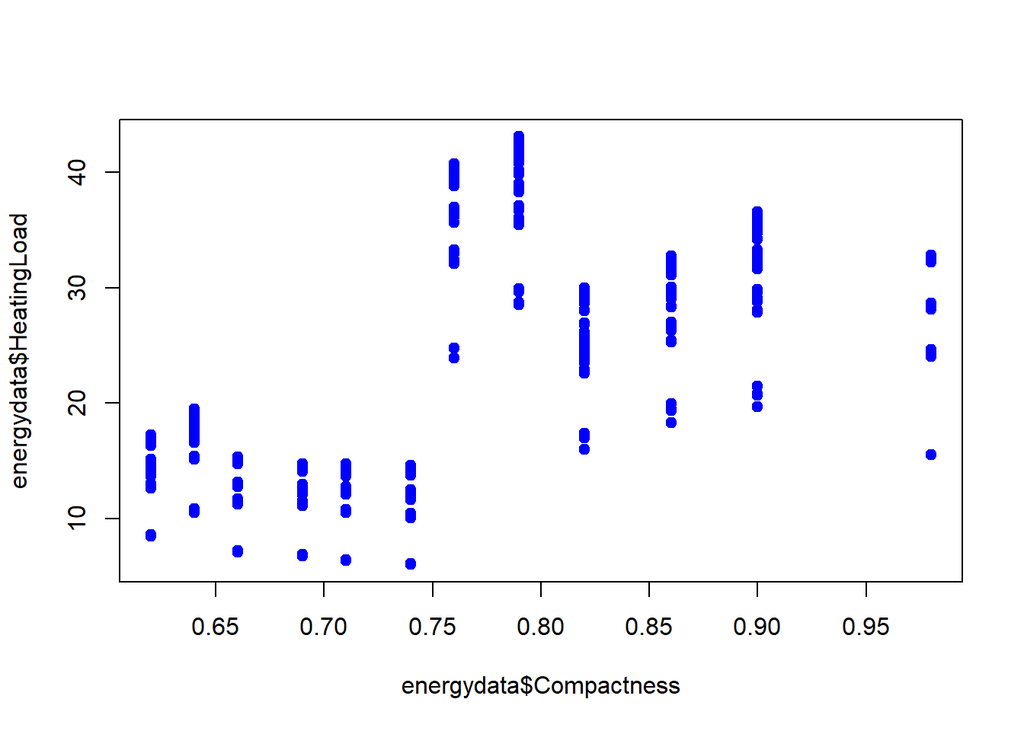

```r
plot(energydata$Compactness, energydata$HeatingLoad, pch = 19, col = "blue")
```

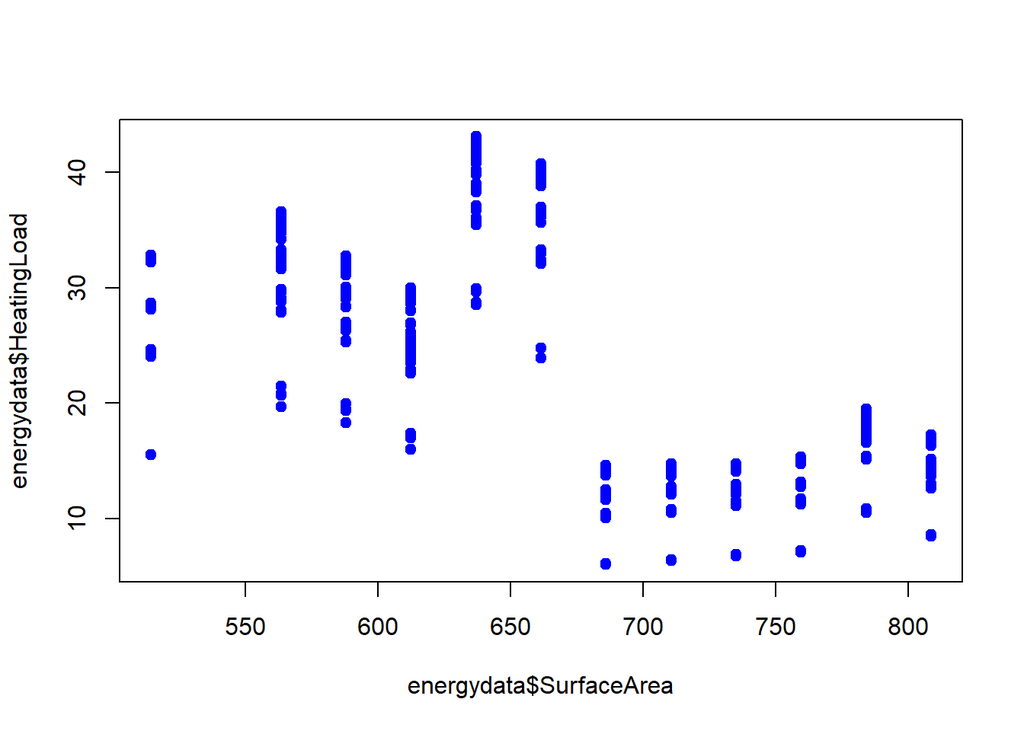

```r
plot(energydata$SurfaceArea, energydata$HeatingLoad, pch = 19, col = "blue")
```

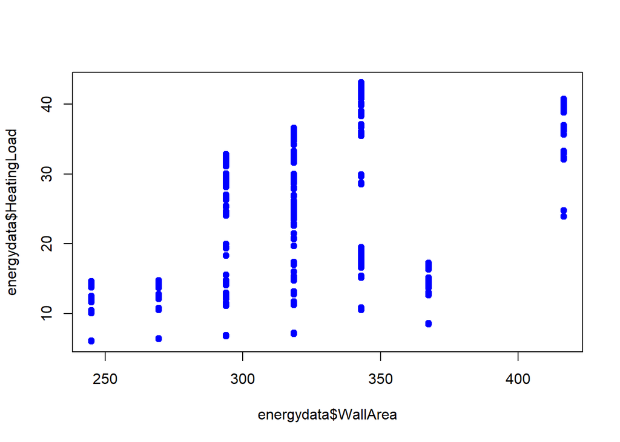

```r
plot(energydata$WallArea, energydata$HeatingLoad, pch = 19, col = "blue")
```

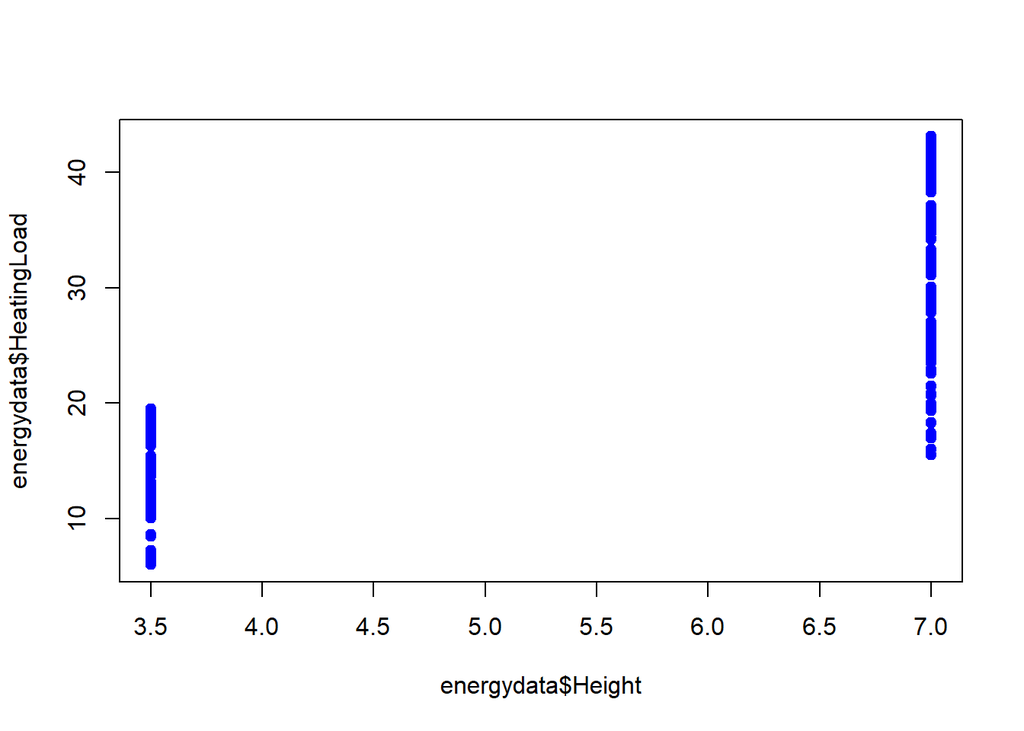

```r
plot(energydata$Height, energydata$HeatingLoad, pch = 19, col = "blue")
```

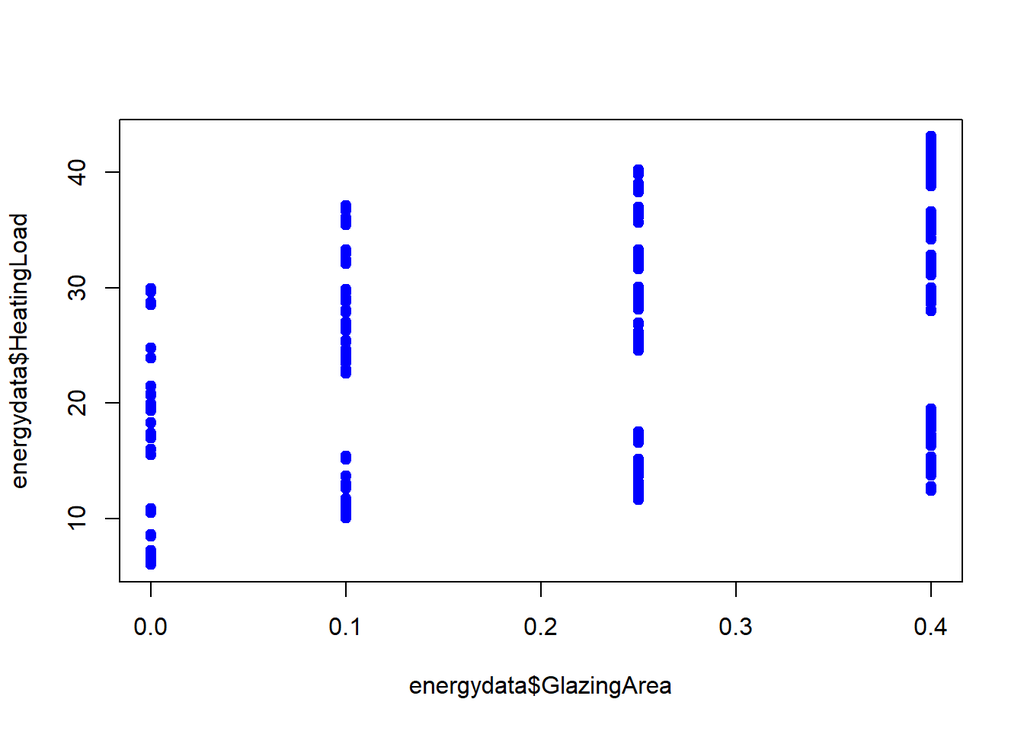

```r
plot(energydata$GlazingArea, energydata$HeatingLoad, pch = 19, col = "blue")
```

11b : Any prominent non-linearity in any plot? Yes. It seems that GlazingArea and HeatingLoad have a non-linear relation.

11c : fit a linear model on HeatingLoad vs remaining variables but introduce non-linear term(s) as per the observation above

```r
lmFit5 <- update(lmFit4, ~ . + I(GlazingArea^2), data = energydata)
```

11d : did the R-squared values improve, as expected?

```r
summary(lmFit5)
```

```
##
## Call:
## lm(formula = HeatingLoad ~ Compactness + SurfaceArea + WallArea +
##     Height + GlazingArea + I(GlazingArea^2), data = energydata)
##
## Residuals:
##     Min      1Q  Median      3Q     Max
## -8.7015 -1.3782 -0.0314  1.2884  7.7634
##
## Coefficients:
##                    Estimate Std. Error t value Pr(>|t|)
## (Intercept)       87.051767  19.743873   4.409 1.20e-05 ***
## Compactness      -67.698940  10.689513  -6.333 4.32e-10 ***
## SurfaceArea       -0.090691   0.017735  -5.114 4.09e-07 ***
## WallArea           0.061656   0.006934   8.892  < 2e-16 ***
## Height             4.150523   0.349783  11.866  < 2e-16 ***
## GlazingArea       41.805105   3.560952  11.740  < 2e-16 ***
## I(GlazingArea^2) -46.166152   7.531786  -6.130 1.48e-09 ***
## ---
## Signif. codes:  0 '***' 0.001 '**' 0.01 '*' 0.05 '.' 0.1 ' ' 1
##
## Residual standard error: 2.911 on 693 degrees of freedom
## Multiple R-squared:  0.9168, Adjusted R-squared:  0.9161
## F-statistic:  1273 on 6 and 693 DF,  p-value: < 2.2e-16
```

11e : is the non-linear term introduced significant? Yes, the term I(GlazingArea^2) is significant (p-value = 1.48e-09).

11f : more non-linear terms should be included? May be. It seems that we still have SurfaceArea, with non-linearity.

11g : fit a linear model on HeatingLoad vs remaining variables but introduce non-linear term(s) as per the observation above

```r
lmFit6 <- update(lmFit5, ~ . + I(SurfaceArea^2), data = energydata)
```

11h : did the R-squared values improve, as expected?

```r
summary(lmFit6)
```

```
##
## Call:
## lm(formula = HeatingLoad ~ Compactness + SurfaceArea + WallArea +
##     Height + GlazingArea + I(GlazingArea^2) + I(SurfaceArea^2),
##     data = energydata)
##
## Residuals:
##     Min      1Q  Median      3Q     Max
## -6.9359 -1.5666  0.0721  1.3882  7.2222
##
## Coefficients:
##                    Estimate Std. Error t value Pr(>|t|)
## (Intercept)      -1.364e+03  1.345e+02 -10.136  < 2e-16 ***
## Compactness       5.462e+02  5.727e+01   9.538  < 2e-16 ***
## SurfaceArea       2.051e+00  1.975e-01  10.387  < 2e-16 ***
## WallArea          3.360e-02  6.911e-03   4.862 1.44e-06 ***
## Height            7.453e+00  4.435e-01  16.805  < 2e-16 ***
## GlazingArea       4.202e+01  3.293e+00  12.761  < 2e-16 ***
## I(GlazingArea^2) -4.676e+01  6.965e+00  -6.714 3.95e-11 ***
## I(SurfaceArea^2) -1.015e-03  9.322e-05 -10.884  < 2e-16 ***
## ---
## Signif. codes:  0 '***' 0.001 '**' 0.01 '*' 0.05 '.' 0.1 ' ' 1
##
## Residual standard error: 2.691 on 692 degrees of freedom
## Multiple R-squared:  0.929,  Adjusted R-squared:  0.9283
## F-statistic:  1293 on 7 and 692 DF,  p-value: < 2.2e-16
```

Yes, they did. In fact, it is quite a lot of improvement.

11i : is the non-linear term introduced significant? Yes, the term I(SurfaceArea^2) is significant (p-value < 2e-16).

11j : more non-linear terms should be included? May be. It seems that we still have Compactness, with non-linearity.

11k : fit a linear model on HeatingLoad vs remaining variables but introduce non-linear term(s) as per the observation above

```r
lmFit7 <- update(lmFit6, ~ . + I(Compactness^2), data = energydata)
```

11l : did the R-squared values improve, as expected?

```r
summary(lmFit7)
```

```
##
## Call:
## lm(formula = HeatingLoad ~ Compactness + SurfaceArea + WallArea +
##     Height + GlazingArea + I(GlazingArea^2) + I(SurfaceArea^2) +
##     I(Compactness^2), data = energydata)
##
## Residuals:
##     Min      1Q  Median      3Q     Max
## -6.6526 -1.6852  0.0183  1.7087  6.2287
##
## Coefficients:
##                    Estimate Std. Error t value Pr(>|t|)
## (Intercept)      -1.654e+03  1.350e+02 -12.250  < 2e-16 ***
## Compactness      -1.740e+02  1.102e+02  -1.579    0.115
## SurfaceArea       3.447e+00  2.651e-01  13.002  < 2e-16 ***
## WallArea         -1.365e-02  9.132e-03  -1.495    0.135
## Height            1.079e+01  6.144e-01  17.562  < 2e-16 ***
## GlazingArea       4.216e+01  3.167e+00  13.312  < 2e-16 ***
## I(GlazingArea^2) -4.713e+01  6.699e+00  -7.034 4.82e-12 ***
## I(SurfaceArea^2) -1.918e-03  1.496e-04 -12.823  < 2e-16 ***
## I(Compactness^2)  5.293e+02  7.014e+01   7.547 1.41e-13 ***
## ---
## Signif. codes:  0 '***' 0.001 '**' 0.01 '*' 0.05 '.' 0.1 ' ' 1
##
## Residual standard error: 2.589 on 691 degrees of freedom
## Multiple R-squared:  0.9344, Adjusted R-squared:  0.9336
## F-statistic:  1230 on 8 and 691 DF,  p-value: < 2.2e-16
```

Yes, they did improve the Multiple R-squared and Adjusted R-squared values

11m : are all the remaining variables still significant? No, it leaves some of the remaining variables as less significant. Hence go back to best model so far which is model lmFit6

```r
summary(lmFit6)
```

```
##
## Call:
## lm(formula = HeatingLoad ~ Compactness + SurfaceArea + WallArea +
##     Height + GlazingArea + I(GlazingArea^2) + I(SurfaceArea^2),
##     data = energydata)
##
## Residuals:
##     Min      1Q  Median      3Q     Max
## -6.9359 -1.5666  0.0721  1.3882  7.2222
##
## Coefficients:
##                    Estimate Std. Error t value Pr(>|t|)
## (Intercept)      -1.364e+03  1.345e+02 -10.136  < 2e-16 ***
## Compactness       5.462e+02  5.727e+01   9.538  < 2e-16 ***
## SurfaceArea       2.051e+00  1.975e-01  10.387  < 2e-16 ***
## WallArea          3.360e-02  6.911e-03   4.862 1.44e-06 ***
## Height            7.453e+00  4.435e-01  16.805  < 2e-16 ***
## GlazingArea       4.202e+01  3.293e+00  12.761  < 2e-16 ***
## I(GlazingArea^2) -4.676e+01  6.965e+00  -6.714 3.95e-11 ***
## I(SurfaceArea^2) -1.015e-03  9.322e-05 -10.884  < 2e-16 ***
## ---
## Signif. codes:  0 '***' 0.001 '**' 0.01 '*' 0.05 '.' 0.1 ' ' 1
##
## Residual standard error: 2.691 on 692 degrees of freedom
## Multiple R-squared:  0.929,  Adjusted R-squared:  0.9283
## F-statistic:  1293 on 7 and 692 DF,  p-value: < 2.2e-16
```

Step 12 : Check for Non-linear mutual Interactions

12a : fit a linear model on HeatingLoad vs remaining variables but introduce a non-linear interaction term between the variables that showed prominent trends of non-linearity previously

```r
lmFit8 <- update(lmFit6, ~ . + GlazingArea:SurfaceArea, data = energydata)
```

12b : did the R-squared values improve, as expected?

```r
summary(lmFit8)
```

```
##
## Call:
## lm(formula = HeatingLoad ~ Compactness + SurfaceArea + WallArea +
##     Height + GlazingArea + I(GlazingArea^2) + I(SurfaceArea^2) +
##     SurfaceArea:GlazingArea, data = energydata)
##
## Residuals:
##     Min      1Q  Median      3Q     Max
## -6.5886 -1.7670  0.1614  1.2398  7.1498
##
## Coefficients:
##                           Estimate Std. Error t value Pr(>|t|)
## (Intercept)             -1.384e+03  1.296e+02 -10.684  < 2e-16 ***
## Compactness              5.516e+02  5.515e+01  10.001  < 2e-16 ***
## SurfaceArea              2.081e+00  1.902e-01  10.938  < 2e-16 ***
## WallArea                 3.420e-02  6.655e-03   5.139 3.59e-07 ***
## Height                   7.435e+00  4.271e-01  17.409  < 2e-16 ***
## GlazingArea              8.342e+01  6.408e+00  13.019  < 2e-16 ***
## I(GlazingArea^2)        -4.553e+01  6.709e+00  -6.787 2.47e-11 ***
## I(SurfaceArea^2)        -1.021e-03  8.977e-05 -11.374  < 2e-16 ***
## SurfaceArea:GlazingArea -6.248e-02  8.402e-03  -7.436 3.09e-13 ***
## ---
## Signif. codes:  0 '***' 0.001 '**' 0.01 '*' 0.05 '.' 0.1 ' ' 1
##
## Residual standard error: 2.592 on 691 degrees of freedom
## Multiple R-squared:  0.9343, Adjusted R-squared:  0.9335
## F-statistic:  1227 on 8 and 691 DF,  p-value: < 2.2e-16
```

Yes, they did slightly improve compared to previous model lmFit6.

12c : are all the remaining variables still significant? Yes, all remaining variables remain significant, GlazingArea:SurfaceArea is significant (p-value = 3.09e-13)

Step 13 : Check the (so far) Best Model more carefully

13a : print the “summary” of the Best Model (so far)

```r
summary(lmFit8)
```

```
##
## Call:
## lm(formula = HeatingLoad ~ Compactness + SurfaceArea + WallArea +
##     Height + GlazingArea + I(GlazingArea^2) + I(SurfaceArea^2) +
##     SurfaceArea:GlazingArea, data = energydata)
##
## Residuals:
##     Min      1Q  Median      3Q     Max
## -6.5886 -1.7670  0.1614  1.2398  7.1498
##
## Coefficients:
##                           Estimate Std. Error t value Pr(>|t|)
## (Intercept)             -1.384e+03  1.296e+02 -10.684  < 2e-16 ***
## Compactness              5.516e+02  5.515e+01  10.001  < 2e-16 ***
## SurfaceArea              2.081e+00  1.902e-01  10.938  < 2e-16 ***
## WallArea                 3.420e-02  6.655e-03   5.139 3.59e-07 ***
## Height                   7.435e+00  4.271e-01  17.409  < 2e-16 ***
## GlazingArea              8.342e+01  6.408e+00  13.019  < 2e-16 ***
## I(GlazingArea^2)        -4.553e+01  6.709e+00  -6.787 2.47e-11 ***
## I(SurfaceArea^2)        -1.021e-03  8.977e-05 -11.374  < 2e-16 ***
## SurfaceArea:GlazingArea -6.248e-02  8.402e-03  -7.436 3.09e-13 ***
## ---
## Signif. codes:  0 '***' 0.001 '**' 0.01 '*' 0.05 '.' 0.1 ' ' 1
##
## Residual standard error: 2.592 on 691 degrees of freedom
## Multiple R-squared:  0.9343, Adjusted R-squared:  0.9335
## F-statistic:  1227 on 8 and 691 DF,  p-value: < 2.2e-16
```

13b : check the model for potential outliers

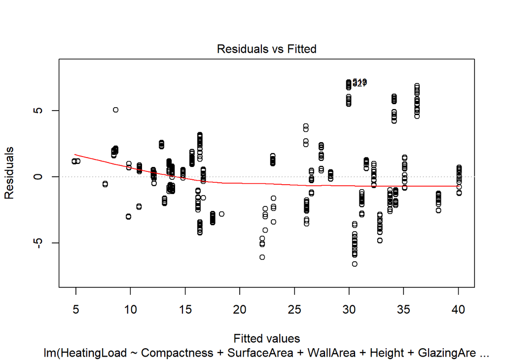

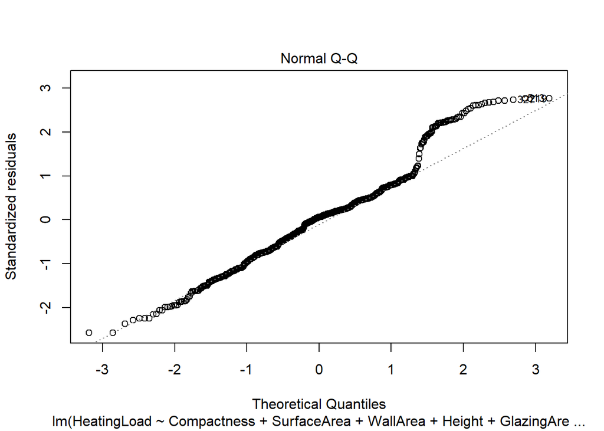

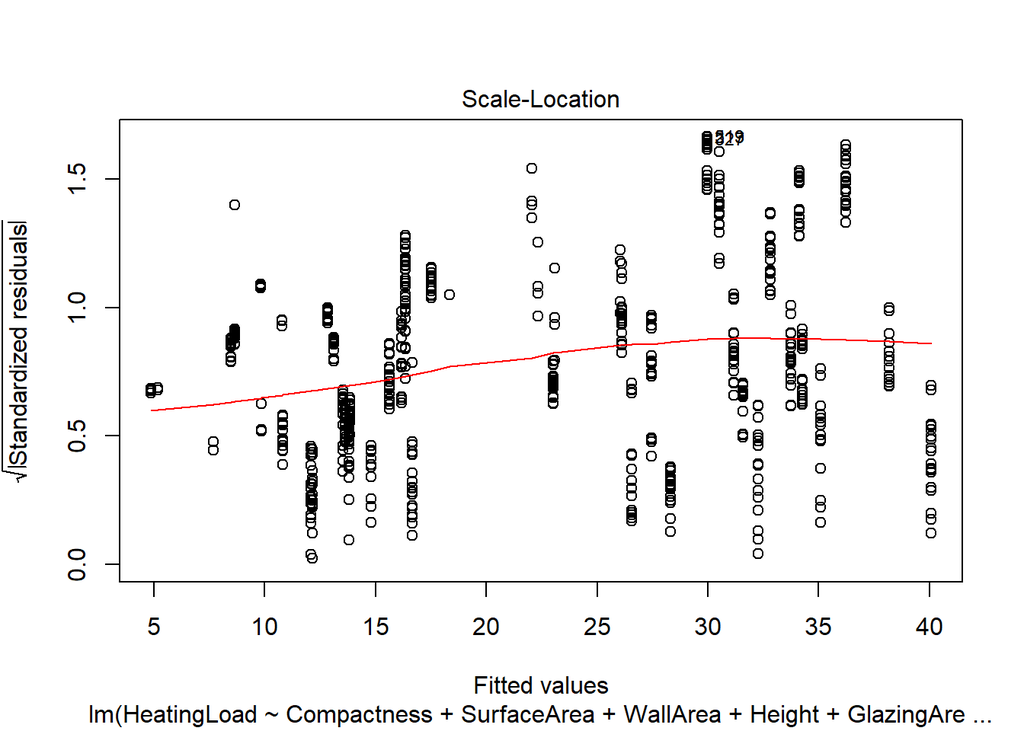

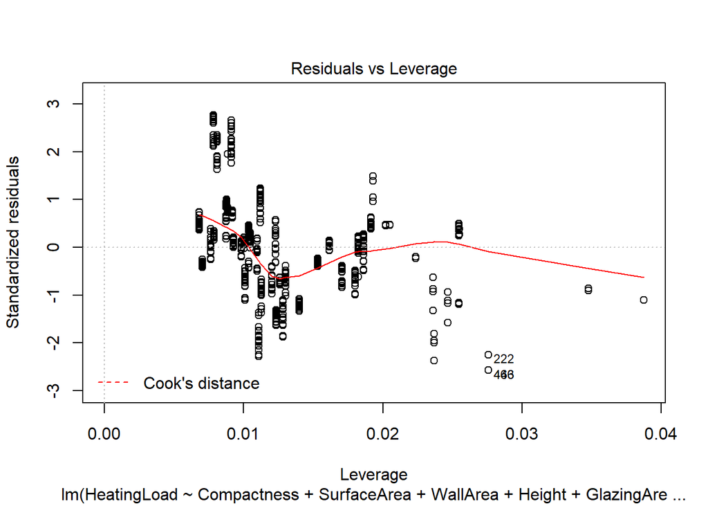

```r
plot(lmFit8)
```

13c : remove outliers and high-leverage points

```r
cd <- cooks.distance(lmFit8)
```

Only selecting rows with less than 4 outliers

```r
energydata.clean <- energydata[abs(cd) < 4/nrow(energydata), ]
nrow(energydata.clean)
```

```
## [1] 670
```

13d : fit the best model to the clean dataset

```r
formula(lmFit8)
```

```
## HeatingLoad ~ Compactness + SurfaceArea + WallArea + Height +
##     GlazingArea + I(GlazingArea^2) + I(SurfaceArea^2) + SurfaceArea:GlazingArea
```

```r
lmFit <- lm(formula(lmFit8), data = energydata.clean)
```

REPEATING STEPS 6 TO 13 for Linear Regression on CoolingLoad

Step 6 : Perform Linear Regression on CoolingLoad

6a : fit a linear model on CoolingLoad vs all other variables Backward method consider all variables and removing variables one by one

As the prediction is for CoolingLoad and HeatingLoad separately, exclude HeatingLoad variable from the CoolingLoad model

```r
lmFit1_c <- lm(CoolingLoad~ .-HeatingLoad, data = energydata)
```

6b : display the “summary” of the linear model

```r
summary(lmFit1_c)
```

```
##
## Call:
## lm(formula = CoolingLoad ~ . - HeatingLoad, data = energydata)
##
## Residuals:
##     Min      1Q  Median      3Q     Max
## -8.5199 -1.5773 -0.2403  1.4136 11.1359
##
## Coefficients: (1 not defined because of singularities)
##               Estimate Std. Error t value Pr(>|t|)
## (Intercept) 100.379171  21.802708   4.604 4.93e-06 ***
## Compactness -72.720579  11.797880  -6.164 1.21e-09 ***
## SurfaceArea  -0.090971   0.019572  -4.648 4.02e-06 ***
## WallArea      0.045735   0.007653   5.976 3.66e-09 ***
## RoofArea            NA         NA      NA       NA
## Height        4.242786   0.386076  10.990  < 2e-16 ***
## Orientation   0.096339   0.108786   0.886    0.376
## GlazingArea  14.734599   0.932098  15.808  < 2e-16 ***
## GAreaDist     0.075319   0.080727   0.933    0.351
## ---
## Signif. codes:  0 '***' 0.001 '**' 0.01 '*' 0.05 '.' 0.1 ' ' 1
##
## Residual standard error: 3.212 on 692 degrees of freedom
## Multiple R-squared:  0.8863, Adjusted R-squared:  0.8852
## F-statistic: 770.6 on 7 and 692 DF,  p-value: < 2.2e-16
```

6c : what is the residual standard error of the model? Residual standard error: 3.212 on 692 degrees of freedom

6d : what is the Multiple R-squared of the model? Multiple R-squared: 0.8863

6e : what is the Adjusted R-squared of the model? Adjusted R-squared: 0.8852

6f : why is Adjusted R-Squared less than Multiple R-squared? Because Adjusted R-squared adjusts Multiple R-squared with the number of parameters used in the model, as follows: Adj R^2 = 1 - (1- R^2)*(n-1)/(n-p-1)

6g : which variable to remove from linear model? why? This line “Coefficients: (1 not defined because of singularities)” indicates that R can’t estimate all the parameters because the predictor variables are not all linearly independent. As observed from the p values of all variables, the variable RoofArea p value is NA, this means that the varianble is linearly dependent on the other 8 variables. R’s lm function (and all properly constructed R regression functions as well) will automatically exclude linearly dependent variables . Therefore, remove RoofArea variables first to build the model for CoolingLoad

Step 7 : Build an Updated Model removing Variables

```r
lmFit2_c <- update(lmFit1_c, ~ . - RoofArea, data = energydata)
```

7b : display the “summary” of the updated linear model

```r
summary(lmFit2_c)
```

```
##
## Call:
## lm(formula = CoolingLoad ~ Compactness + SurfaceArea + WallArea +
##     Height + Orientation + GlazingArea + GAreaDist, data = energydata)
##
## Residuals:
##     Min      1Q  Median      3Q     Max
## -8.5199 -1.5773 -0.2403  1.4136 11.1359
##
## Coefficients:
##               Estimate Std. Error t value Pr(>|t|)
## (Intercept) 100.379171  21.802708   4.604 4.93e-06 ***
## Compactness -72.720579  11.797880  -6.164 1.21e-09 ***
## SurfaceArea  -0.090971   0.019572  -4.648 4.02e-06 ***
## WallArea      0.045735   0.007653   5.976 3.66e-09 ***
## Height        4.242786   0.386076  10.990  < 2e-16 ***
## Orientation   0.096339   0.108786   0.886    0.376
## GlazingArea  14.734599   0.932098  15.808  < 2e-16 ***
## GAreaDist     0.075319   0.080727   0.933    0.351
## ---
## Signif. codes:  0 '***' 0.001 '**' 0.01 '*' 0.05 '.' 0.1 ' ' 1
##
## Residual standard error: 3.212 on 692 degrees of freedom
## Multiple R-squared:  0.8863, Adjusted R-squared:  0.8852
## F-statistic: 770.6 on 7 and 692 DF,  p-value: < 2.2e-16
```

7c : did the Multiple R-squared improve? why? No. It can’t improve as we removed a variable. Multiple R-squared: 0.8863

7d : did the Adjusted R-squared improve? why? No. Because we removed a variable that will have no significance in the model. Adjusted R-squared: 0.8852

Now, consider the least significant variable to remove 7e : which variable is least significant? why? It seems that Orientation is least significant (p-value = 0.376)

Step 8 : Build an Updated Model removing Variables

8a : fit a linear model with all remaining variables but the ones with the least significance in the previous model

```r
lmFit3_c <- update(lmFit2_c, ~ . - Orientation, data = energydata)
```

8b : display the “summary” of the updated linear model

```r
summary(lmFit3_c)
```

```
##
## Call:
## lm(formula = CoolingLoad ~ Compactness + SurfaceArea + WallArea +
##     Height + GlazingArea + GAreaDist, data = energydata)
##
## Residuals:
##    Min     1Q Median     3Q    Max
## -8.464 -1.619 -0.239  1.398 11.286
##
## Coefficients:
##               Estimate Std. Error t value Pr(>|t|)
## (Intercept) 101.035099  21.786731   4.637 4.22e-06 ***
## Compactness -72.857349  11.795032  -6.177 1.11e-09 ***
## SurfaceArea  -0.091288   0.019566  -4.666 3.69e-06 ***
## WallArea      0.045852   0.007651   5.993 3.31e-09 ***
## Height        4.234604   0.385905  10.973  < 2e-16 ***
## GlazingArea  14.731765   0.931947  15.808  < 2e-16 ***
## GAreaDist     0.076951   0.080694   0.954    0.341
## ---
## Signif. codes:  0 '***' 0.001 '**' 0.01 '*' 0.05 '.' 0.1 ' ' 1
##
## Residual standard error: 3.212 on 693 degrees of freedom
## Multiple R-squared:  0.8862, Adjusted R-squared:  0.8852
## F-statistic: 899.2 on 6 and 693 DF,  p-value: < 2.2e-16
```

8c : did the Multiple R-squared improve? why? No. It can’t improve as we removed a variable. Multiple R-squared: 0.8862

8d : did the Adjusted R-squared improve? why? No change observed after the removal of the least significant variable. Adjusted R-squared: 0.8852

8e : which variable is least significant? why? It seems that GAreaDist is least significant (p-value = 0.341)

Step 9 : Build an Updated Model removing Variables

9a : fit a linear model with all the remaining variables but the ones with the least significance in the previous model

```r
lmFit4_c <- update(lmFit3_c, ~ . - GAreaDist, data = energydata)
```

9b : display the “summary” of the updated linear model

```r
summary(lmFit4_c)
```

```
##
## Call:
## lm(formula = CoolingLoad ~ Compactness + SurfaceArea + WallArea +
##     Height + GlazingArea, data = energydata)
##
## Residuals:
##     Min      1Q  Median      3Q     Max
## -8.6298 -1.5933 -0.2551  1.4072 11.1919
##
## Coefficients:
##               Estimate Std. Error t value Pr(>|t|)
## (Intercept) 100.626620  21.781098   4.620 4.58e-06 ***
## Compactness -72.508092  11.788575  -6.151 1.30e-09 ***
## SurfaceArea  -0.090815   0.019558  -4.643 4.10e-06 ***
## WallArea      0.045751   0.007649   5.981 3.55e-09 ***
## Height        4.238865   0.385854  10.986  < 2e-16 ***
## GlazingArea  14.942960   0.905191  16.508  < 2e-16 ***
## ---
## Signif. codes:  0 '***' 0.001 '**' 0.01 '*' 0.05 '.' 0.1 ' ' 1
##
## Residual standard error: 3.211 on 694 degrees of freedom
## Multiple R-squared:  0.886,  Adjusted R-squared:  0.8852
## F-statistic:  1079 on 5 and 694 DF,  p-value: < 2.2e-16
```

9c : did the Multiple R-squared improve? why? No. It can’t improve as we removed a variable. Multiple R-squared: 0.886

9d : did the Adjusted R-squared improve? why? Still no change observed in Adjusted R-squared value. Adjusted R-squared: 0.8852 But by removing GAreaDist, we got all the remaining variables highly significant, and the F-statistic improved compared to the previous model.

Step 10 : Judge the overall status of the Model

10a : more variables should be removed? why? No, it seems that all remaining variables are highly significant.

Step 11 : Check for Non-linear Relations with Variables

11a : plot CoolingLoad vs all the remaining variables

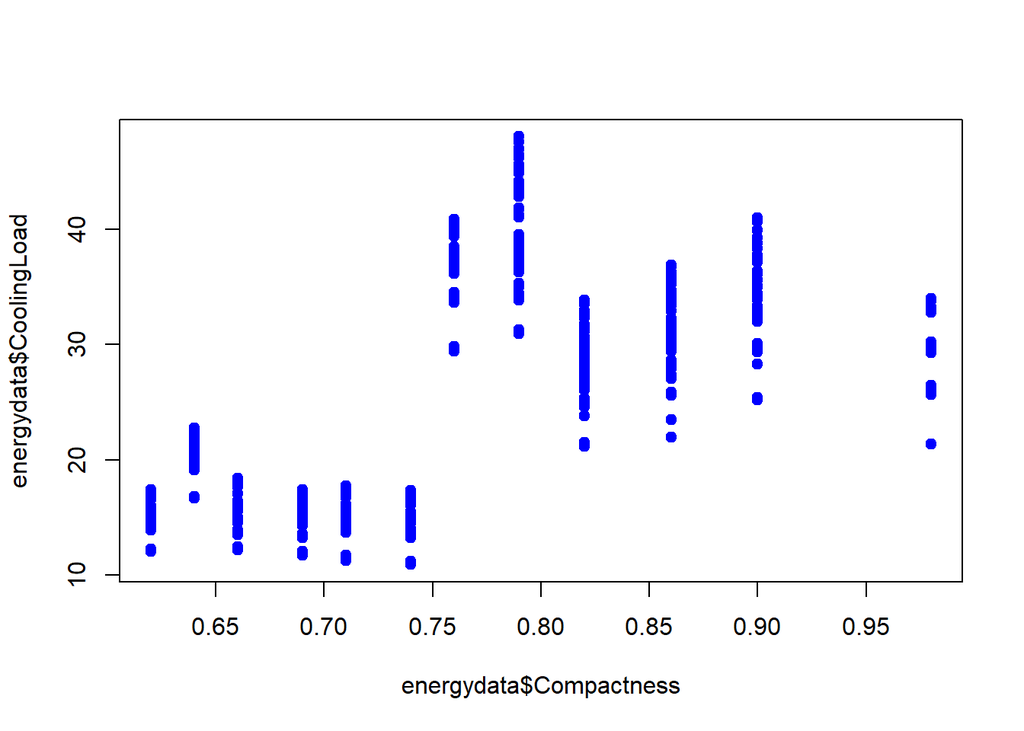

```r
plot(energydata$Compactness, energydata$CoolingLoad, pch = 19, col = "blue")
```

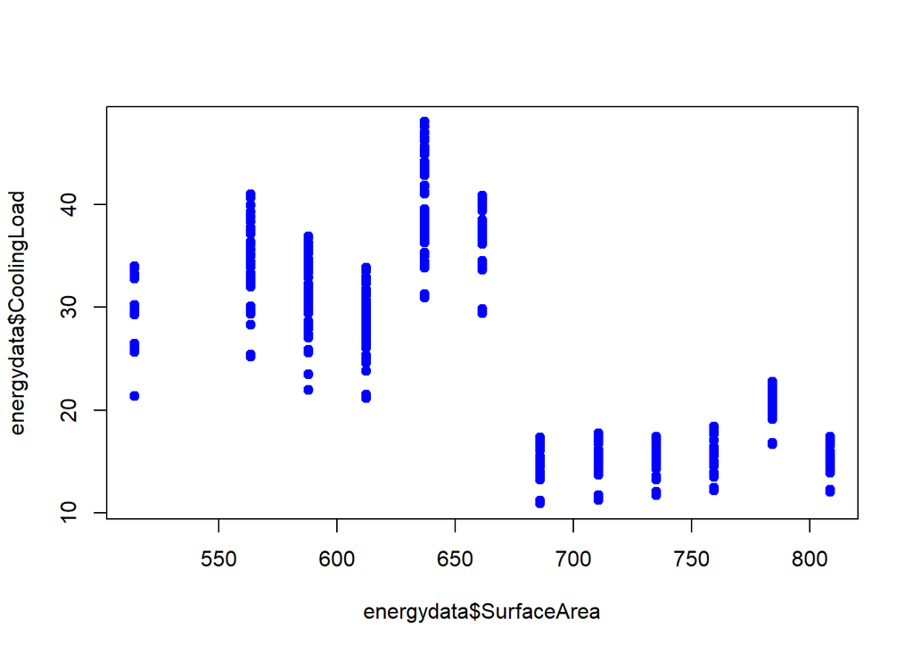

```r
plot(energydata$SurfaceArea, energydata$CoolingLoad, pch = 19, col = "blue")
```

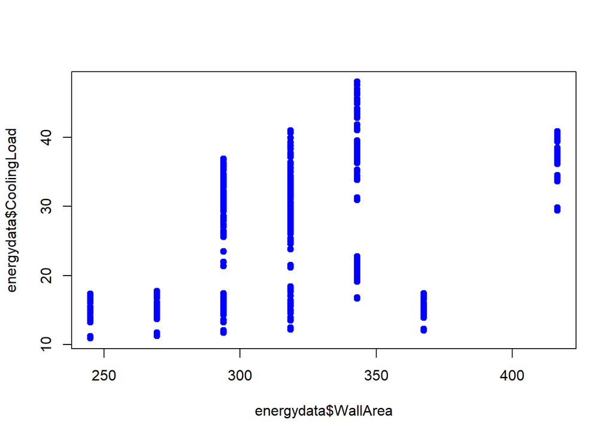

```r
plot(energydata$WallArea, energydata$CoolingLoad, pch = 19, col = "blue")
```

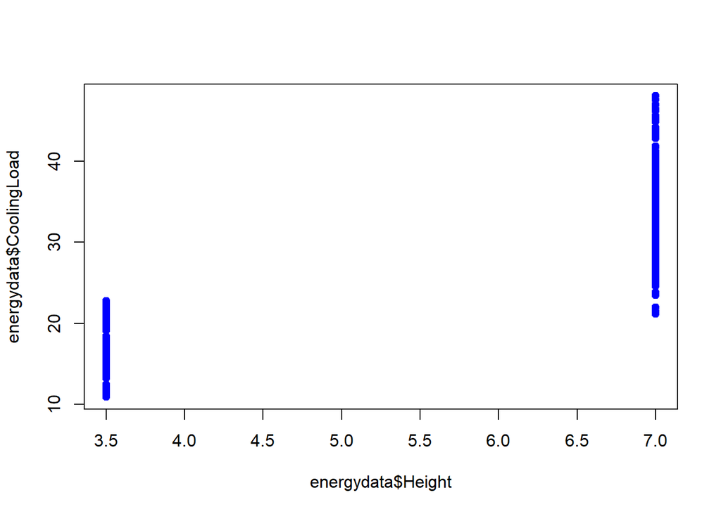

```r
plot(energydata$Height, energydata$CoolingLoad, pch = 19, col = "blue")
```

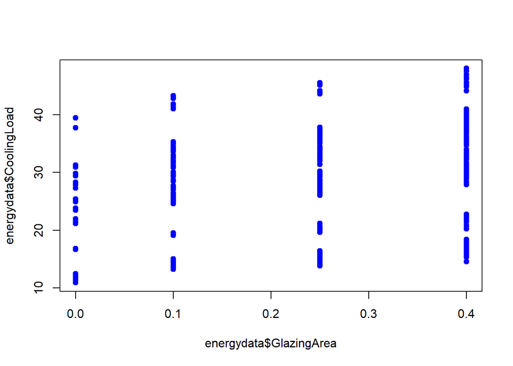

```r
plot(energydata$GlazingArea, energydata$CoolingLoad, pch = 19, col = "blue")
```

11b : Any prominent non-linearity in any plot? Yes. It seems that GlazingArea and CoolingLoad have a non-linear relation.

11c : fit a linear model on CoolingLoad vs remaining variables but introduce non-linear term(s) as per the observation above

```r
lmFit5_c <- update(lmFit4_c, ~ . + I(GlazingArea^2), data = energydata)
```

11d : did the R-squared values improve, as expected?

```r
summary(lmFit5_c)
```

```
##
## Call:
## lm(formula = CoolingLoad ~ Compactness + SurfaceArea + WallArea +
##     Height + GlazingArea + I(GlazingArea^2), data = energydata)
##
## Residuals:
##     Min      1Q  Median      3Q     Max
## -7.9082 -1.5912 -0.3239  1.4372 11.4148
##
## Coefficients:
##                    Estimate Std. Error t value Pr(>|t|)
## (Intercept)      101.624399  21.702202   4.683 3.41e-06 ***
## Compactness      -73.439401  11.749770  -6.250 7.16e-10 ***
## SurfaceArea       -0.092335   0.019494  -4.737 2.64e-06 ***
## WallArea           0.046120   0.007622   6.051 2.36e-09 ***
## Height             4.218586   0.384477  10.972  < 2e-16 ***
## GlazingArea       24.495597   3.914151   6.258 6.82e-10 ***
## I(GlazingArea^2) -20.763366   8.278838  -2.508   0.0124 *
## ---
## Signif. codes:  0 '***' 0.001 '**' 0.01 '*' 0.05 '.' 0.1 ' ' 1
##
## Residual standard error: 3.199 on 693 degrees of freedom
## Multiple R-squared:  0.887,  Adjusted R-squared:  0.8861
## F-statistic: 907.1 on 6 and 693 DF,  p-value: < 2.2e-16
```

Yes, they only improved very slightly.

```r
summary(lmFit4_c)
```

```
##
## Call:
## lm(formula = CoolingLoad ~ Compactness + SurfaceArea + WallArea +
##     Height + GlazingArea, data = energydata)
##
## Residuals:
##     Min      1Q  Median      3Q     Max
## -8.6298 -1.5933 -0.2551  1.4072 11.1919
##
## Coefficients:
##               Estimate Std. Error t value Pr(>|t|)
## (Intercept) 100.626620  21.781098   4.620 4.58e-06 ***
## Compactness -72.508092  11.788575  -6.151 1.30e-09 ***
## SurfaceArea  -0.090815   0.019558  -4.643 4.10e-06 ***
## WallArea      0.045751   0.007649   5.981 3.55e-09 ***
## Height        4.238865   0.385854  10.986  < 2e-16 ***
## GlazingArea  14.942960   0.905191  16.508  < 2e-16 ***
## ---
## Signif. codes:  0 '***' 0.001 '**' 0.01 '*' 0.05 '.' 0.1 ' ' 1
##
## Residual standard error: 3.211 on 694 degrees of freedom
## Multiple R-squared:  0.886,  Adjusted R-squared:  0.8852
## F-statistic:  1079 on 5 and 694 DF,  p-value: < 2.2e-16
```

11f : they are other non-linear terms should be included? May be. It seems that we still have SurfaceArea, with non-linearity.

11g : fit a linear model on CoolingLoad vs remaining variables but introduce non-linear term(s) as per the observation above

```r
lmFit6_c <- update(lmFit4_c, ~ . + I(SurfaceArea^2), data = energydata)
```

11h : did the R-squared values improve, as expected?

```r
summary(lmFit6_c)
```

```
##
## Call:
## lm(formula = CoolingLoad ~ Compactness + SurfaceArea + WallArea +
##     Height + GlazingArea + I(SurfaceArea^2), data = energydata)
##
## Residuals:
##     Min      1Q  Median      3Q     Max
## -6.9493 -2.0381  0.0194  1.4359 10.6645
##
## Coefficients:
##                    Estimate Std. Error t value Pr(>|t|)
## (Intercept)      -1.297e+03  1.515e+02  -8.560  < 2e-16 ***
## Compactness       5.188e+02  6.447e+01   8.047  3.7e-15 ***
## SurfaceArea       1.972e+00  2.223e-01   8.870  < 2e-16 ***
## WallArea          1.872e-02  7.779e-03   2.407   0.0164 *
## Height            7.420e+00  4.992e-01  14.862  < 2e-16 ***
## GlazingArea       1.489e+01  8.540e-01  17.432  < 2e-16 ***
## I(SurfaceArea^2) -9.771e-04  1.049e-04  -9.311  < 2e-16 ***
## ---
## Signif. codes:  0 '***' 0.001 '**' 0.01 '*' 0.05 '.' 0.1 ' ' 1
##
## Residual standard error: 3.03 on 693 degrees of freedom
## Multiple R-squared:  0.8987, Adjusted R-squared:  0.8978
## F-statistic:  1025 on 6 and 693 DF,  p-value: < 2.2e-16
```

Yes, the Multiple R-squared and Adjusted R-squared values did improve.

11i : is the non-linear term introduced significant? Yes, the term I(SurfaceArea^2) is significant (p-value < 2e-16). However, it makes the WallArea variable to be less significant (p-value = 0.0164) So we go back to the best model so far lmFit4_c

```r
summary(lmFit4_c)
```

```
##
## Call:
## lm(formula = CoolingLoad ~ Compactness + SurfaceArea + WallArea +
##     Height + GlazingArea, data = energydata)
##
## Residuals:
##     Min      1Q  Median      3Q     Max
## -8.6298 -1.5933 -0.2551  1.4072 11.1919
##
## Coefficients:
##               Estimate Std. Error t value Pr(>|t|)
## (Intercept) 100.626620  21.781098   4.620 4.58e-06 ***
## Compactness -72.508092  11.788575  -6.151 1.30e-09 ***
## SurfaceArea  -0.090815   0.019558  -4.643 4.10e-06 ***
## WallArea      0.045751   0.007649   5.981 3.55e-09 ***
## Height        4.238865   0.385854  10.986  < 2e-16 ***
## GlazingArea  14.942960   0.905191  16.508  < 2e-16 ***
## ---
## Signif. codes:  0 '***' 0.001 '**' 0.01 '*' 0.05 '.' 0.1 ' ' 1
##
## Residual standard error: 3.211 on 694 degrees of freedom
## Multiple R-squared:  0.886,  Adjusted R-squared:  0.8852
## F-statistic:  1079 on 5 and 694 DF,  p-value: < 2.2e-16
```

11j : more non-linear terms should be included? It seems that we still have Compactness, with non-linearity.

11k : fit a linear model on CoolingLoad vs remaining variables but introduce non-linear term(s) as per the observation above

```r
lmFit7_c <- update(lmFit4_c, ~ . + I(Compactness^2), data = energydata)
```

11l : did the R-squared values improve, as expected?

```r
summary(lmFit7_c)
```

```
##
## Call:
## lm(formula = CoolingLoad ~ Compactness + SurfaceArea + WallArea +
##     Height + GlazingArea + I(Compactness^2), data = energydata)
##
## Residuals:
##     Min      1Q  Median      3Q     Max
## -8.2655 -1.7095 -0.2492  1.3651 11.3545
##
## Coefficients:
##                    Estimate Std. Error t value Pr(>|t|)
## (Intercept)      -2.191e+02  1.004e+02  -2.182  0.02947 *
## Compactness       3.317e+02  1.245e+02   2.664  0.00791 **
## SurfaceArea       7.251e-02  5.373e-02   1.350  0.17760
## WallArea          5.285e-02  7.903e-03   6.688 4.67e-11 ***
## Height            4.113e+00  3.852e-01  10.678  < 2e-16 ***
## GlazingArea       1.493e+01  8.990e-01  16.613  < 2e-16 ***
## I(Compactness^2) -1.689e+02  5.180e+01  -3.260  0.00117 **
## ---
## Signif. codes:  0 '***' 0.001 '**' 0.01 '*' 0.05 '.' 0.1 ' ' 1
##
## Residual standard error: 3.189 on 693 degrees of freedom
## Multiple R-squared:  0.8877, Adjusted R-squared:  0.8868
## F-statistic: 913.4 on 6 and 693 DF,  p-value: < 2.2e-16
```

Yes, the Multiple R-squared and Adjusted R-squared values did improve slightly

11m : are all the remaining variables still significant? No, it leaves some of the remaining variables as less significant. Hence go back to best model so far which is model lmFit4_c

```r
summary(lmFit4_c)
```

```
##
## Call:
## lm(formula = CoolingLoad ~ Compactness + SurfaceArea + WallArea +
##     Height + GlazingArea, data = energydata)
##
## Residuals:
##     Min      1Q  Median      3Q     Max
## -8.6298 -1.5933 -0.2551  1.4072 11.1919
##
## Coefficients:
##               Estimate Std. Error t value Pr(>|t|)
## (Intercept) 100.626620  21.781098   4.620 4.58e-06 ***
## Compactness -72.508092  11.788575  -6.151 1.30e-09 ***
## SurfaceArea  -0.090815   0.019558  -4.643 4.10e-06 ***
## WallArea      0.045751   0.007649   5.981 3.55e-09 ***
## Height        4.238865   0.385854  10.986  < 2e-16 ***
## GlazingArea  14.942960   0.905191  16.508  < 2e-16 ***
## ---
## Signif. codes:  0 '***' 0.001 '**' 0.01 '*' 0.05 '.' 0.1 ' ' 1
##
## Residual standard error: 3.211 on 694 degrees of freedom
## Multiple R-squared:  0.886,  Adjusted R-squared:  0.8852
## F-statistic:  1079 on 5 and 694 DF,  p-value: < 2.2e-16
```

11n : more non-linear terms should be included? Maybe, it seems that we still have WallArea, with non-linearity.

11o : fit a linear model on CoolingLoad vs remaining variables but introduce non-linear term(s) as per the observation above

```r
lmFit8_c <- update(lmFit4_c, ~ . + I(WallArea^2), data = energydata)
```

11p : did the R-squared values improve, as expected?

```r
summary(lmFit8_c)
```

```
##
## Call:
## lm(formula = CoolingLoad ~ Compactness + SurfaceArea + WallArea +
##     Height + GlazingArea + I(WallArea^2), data = energydata)
##
## Residuals:
##     Min      1Q  Median      3Q     Max
## -8.8945 -1.6503 -0.4153  1.8053 10.9031
##
## Coefficients:
##                 Estimate Std. Error t value Pr(>|t|)
## (Intercept)    1.655e+02  2.655e+01   6.231 8.04e-10 ***
## Compactness   -1.221e+02  1.665e+01  -7.334 6.25e-13 ***
## SurfaceArea   -1.788e-01  2.862e-02  -6.249 7.23e-10 ***
## WallArea       2.680e-01  5.383e-02   4.979 8.07e-07 ***
## Height         2.678e+00  5.343e-01   5.014 6.79e-07 ***
## GlazingArea    1.499e+01  8.948e-01  16.755  < 2e-16 ***
## I(WallArea^2) -2.945e-04  7.062e-05  -4.171 3.42e-05 ***
## ---
## Signif. codes:  0 '***' 0.001 '**' 0.01 '*' 0.05 '.' 0.1 ' ' 1
##
## Residual standard error: 3.174 on 693 degrees of freedom
## Multiple R-squared:  0.8888, Adjusted R-squared:  0.8879
## F-statistic: 923.3 on 6 and 693 DF,  p-value: < 2.2e-16
```

Yes, the Multiple R-squared and Adjusted R-squared values did improve more than the previous non-linear varible

Step 12 : Check for Non-linear mutual Interactions

12a : fit a linear model on CoolingLoad vs remaining variables but introduce a non-linear interaction term between the variables that showed prominent trends of non-linearity previously

```r
lmFit9_c <- update(lmFit8_c, ~ . + WallArea:SurfaceArea, data = energydata)
```

12b : did the R-squared values improve, as expected?

```r
summary(lmFit9_c)
```

```
##
## Call:
## lm(formula = CoolingLoad ~ Compactness + SurfaceArea + WallArea +
##     Height + GlazingArea + I(WallArea^2) + SurfaceArea:WallArea,
##     data = energydata)
##
## Residuals:
##     Min      1Q  Median      3Q     Max
## -7.1507 -1.6888 -0.0756  1.6795  9.9426
##
## Coefficients:
##                        Estimate Std. Error t value Pr(>|t|)
## (Intercept)          -1.415e+03  1.537e+02  -9.203  < 2e-16 ***
## Compactness           5.370e+02  6.516e+01   8.242 8.51e-16 ***
## SurfaceArea           1.585e+00  1.715e-01   9.245  < 2e-16 ***
## WallArea              9.165e-01  7.991e-02  11.469  < 2e-16 ***
## Height                1.575e+01  1.350e+00  11.667  < 2e-16 ***
## GlazingArea           1.492e+01  8.326e-01  17.918  < 2e-16 ***
## I(WallArea^2)         7.626e-04  1.209e-04   6.307 5.07e-10 ***
## SurfaceArea:WallArea -2.295e-03  2.204e-04 -10.414  < 2e-16 ***
## ---
## Signif. codes:  0 '***' 0.001 '**' 0.01 '*' 0.05 '.' 0.1 ' ' 1
##
## Residual standard error: 2.953 on 692 degrees of freedom
## Multiple R-squared:  0.9039, Adjusted R-squared:  0.9029
## F-statistic: 929.6 on 7 and 692 DF,  p-value: < 2.2e-16
```

Yes, they did improve significantly

12c : are all the remaining variables still significant? Yes, all remaining variables remain significant, wallArea:SurfaceArea is significant (p-value < 2e-16)

Step 13 : Check the (so far) Best Model more carefully

13a : print the “summary” of the Best Model (so far)

```r
summary(lmFit9_c)
```

```
##
## Call:
## lm(formula = CoolingLoad ~ Compactness + SurfaceArea + WallArea +
##     Height + GlazingArea + I(WallArea^2) + SurfaceArea:WallArea,
##     data = energydata)
##
## Residuals:
##     Min      1Q  Median      3Q     Max
## -7.1507 -1.6888 -0.0756  1.6795  9.9426
##
## Coefficients:
##                        Estimate Std. Error t value Pr(>|t|)
## (Intercept)          -1.415e+03  1.537e+02  -9.203  < 2e-16 ***
## Compactness           5.370e+02  6.516e+01   8.242 8.51e-16 ***
## SurfaceArea           1.585e+00  1.715e-01   9.245  < 2e-16 ***
## WallArea              9.165e-01  7.991e-02  11.469  < 2e-16 ***
## Height                1.575e+01  1.350e+00  11.667  < 2e-16 ***
## GlazingArea           1.492e+01  8.326e-01  17.918  < 2e-16 ***
## I(WallArea^2)         7.626e-04  1.209e-04   6.307 5.07e-10 ***
## SurfaceArea:WallArea -2.295e-03  2.204e-04 -10.414  < 2e-16 ***
## ---
## Signif. codes:  0 '***' 0.001 '**' 0.01 '*' 0.05 '.' 0.1 ' ' 1
##
## Residual standard error: 2.953 on 692 degrees of freedom
## Multiple R-squared:  0.9039, Adjusted R-squared:  0.9029
## F-statistic: 929.6 on 7 and 692 DF,  p-value: < 2.2e-16
```

13b : check the model for potential outliers

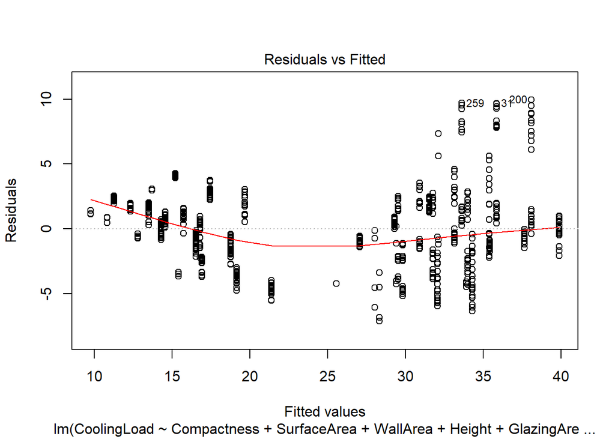

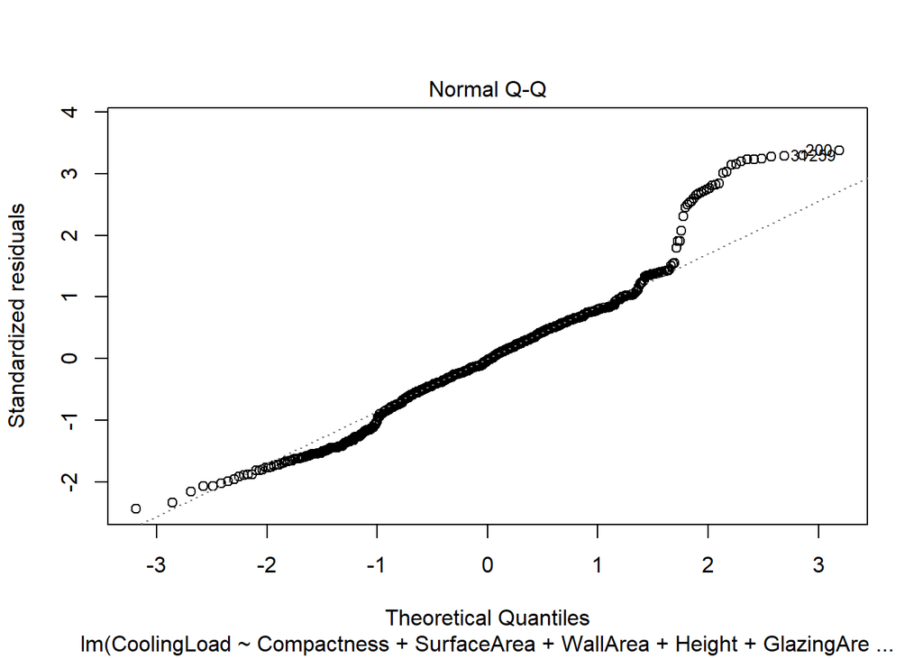

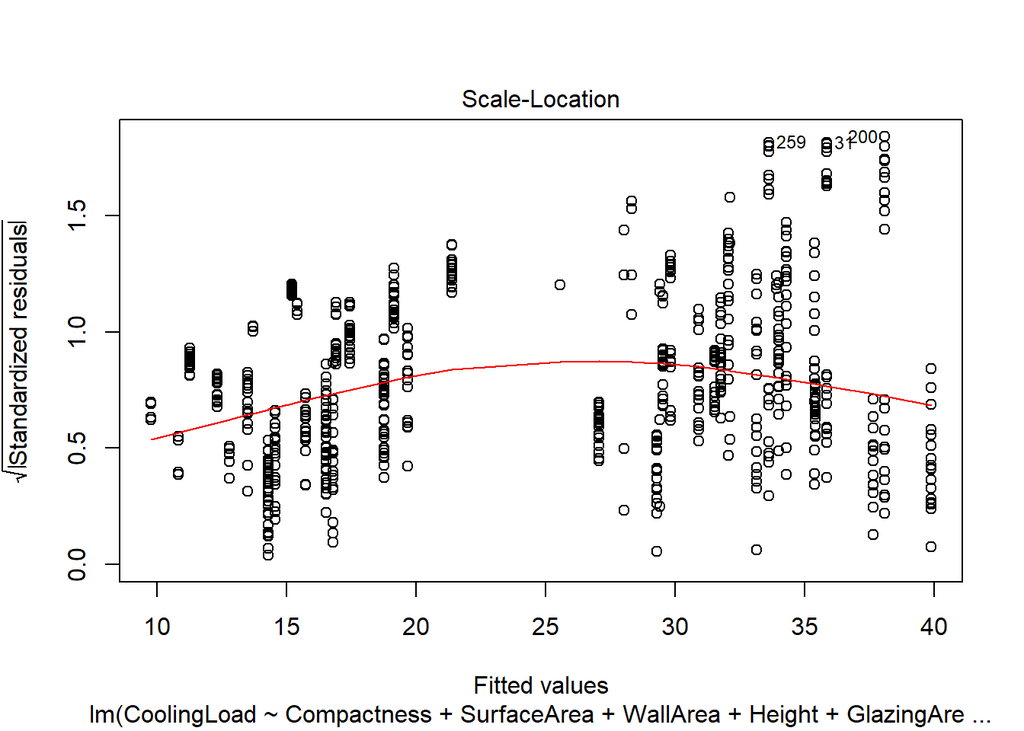

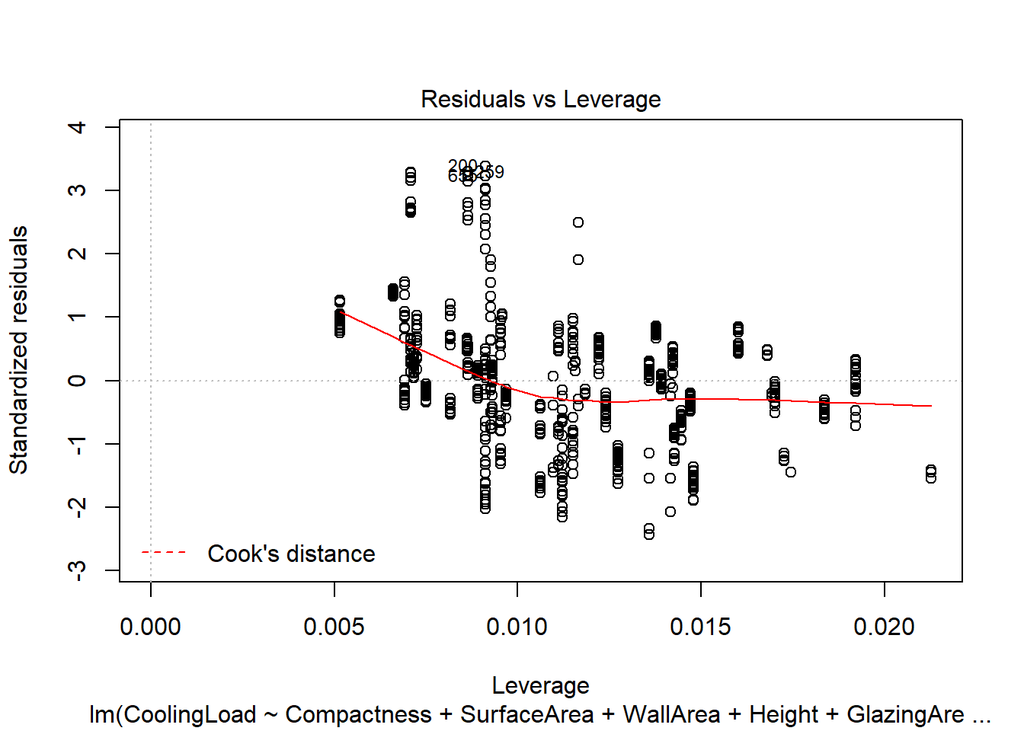

```r
plot(lmFit9_c)
```

13c : remove outliers and high-leverage points

```r
cd <- cooks.distance(lmFit9_c)
```

```r
energydata.clean <- energydata[abs(cd) < 4/nrow(energydata), ]
nrow(energydata.clean)
```

```
## [1] 665
```

13d : fit the best model to the clean dataset

```r
formula(lmFit9_c)
```

```
## CoolingLoad ~ Compactness + SurfaceArea + WallArea + Height +
##     GlazingArea + I(WallArea^2) + SurfaceArea:WallArea
```

```r
lmFit_c <- lm(formula(lmFit9_c), data = energydata.clean)
```

13e : did the performance of the model improve?

```r
summary(lmFit_c)
```

```
##
## Call:
## lm(formula = formula(lmFit9_c), data = energydata.clean)
##
## Residuals:
##     Min      1Q  Median      3Q     Max
## -5.0499 -1.5448 -0.2221  1.4730  7.9644
##
## Coefficients:
##                        Estimate Std. Error t value Pr(>|t|)
## (Intercept)          -9.656e+02  1.217e+02  -7.934 9.17e-15 ***
## Compactness           3.672e+02  5.141e+01   7.143 2.44e-12 ***
## SurfaceArea           1.083e+00  1.357e-01   7.978 6.64e-15 ***
## WallArea              6.474e-01  6.338e-02  10.214  < 2e-16 ***
## Height                1.129e+01  1.071e+00  10.545  < 2e-16 ***
## GlazingArea           1.462e+01  6.608e-01  22.133  < 2e-16 ***
## I(WallArea^2)         5.724e-04  9.445e-05   6.060 2.29e-09 ***
## SurfaceArea:WallArea -1.613e-03  1.749e-04  -9.223  < 2e-16 ***
## ---
## Signif. codes:  0 '***' 0.001 '**' 0.01 '*' 0.05 '.' 0.1 ' ' 1
##
## Residual standard error: 2.27 on 657 degrees of freedom
## Multiple R-squared:  0.9342, Adjusted R-squared:  0.9335
## F-statistic:  1332 on 7 and 657 DF,  p-value: < 2.2e-16
```

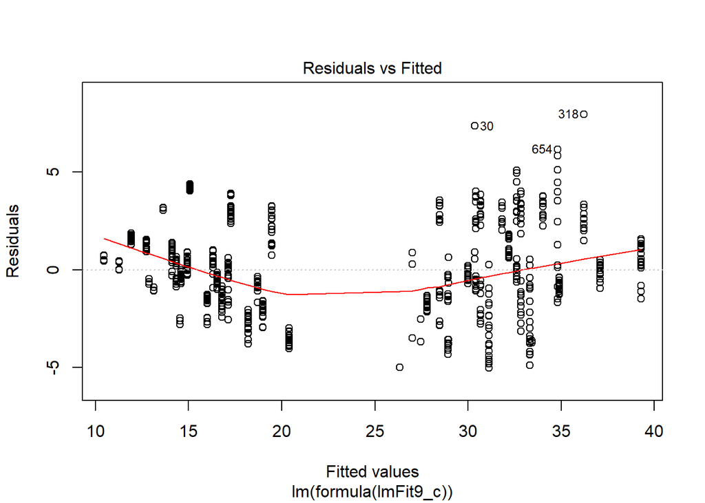

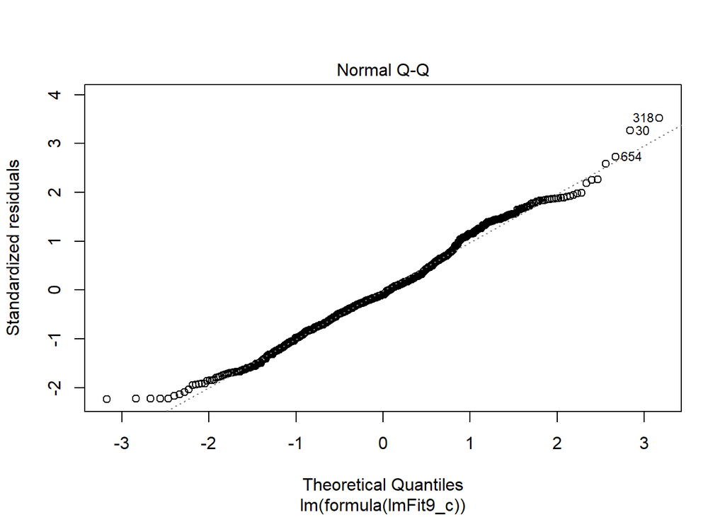

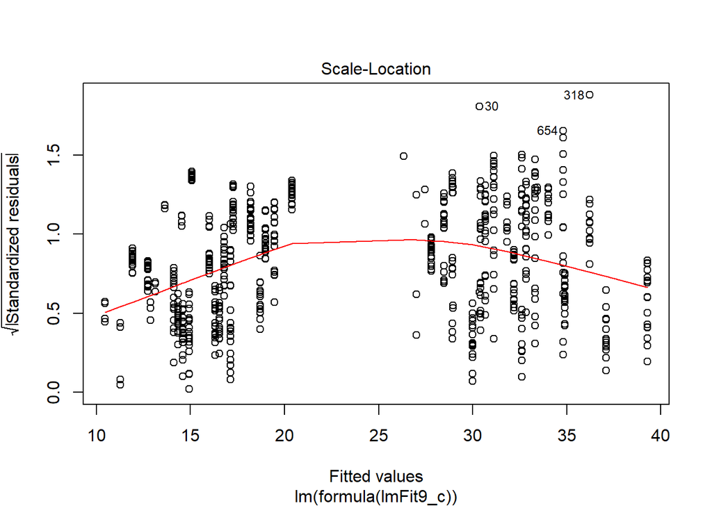

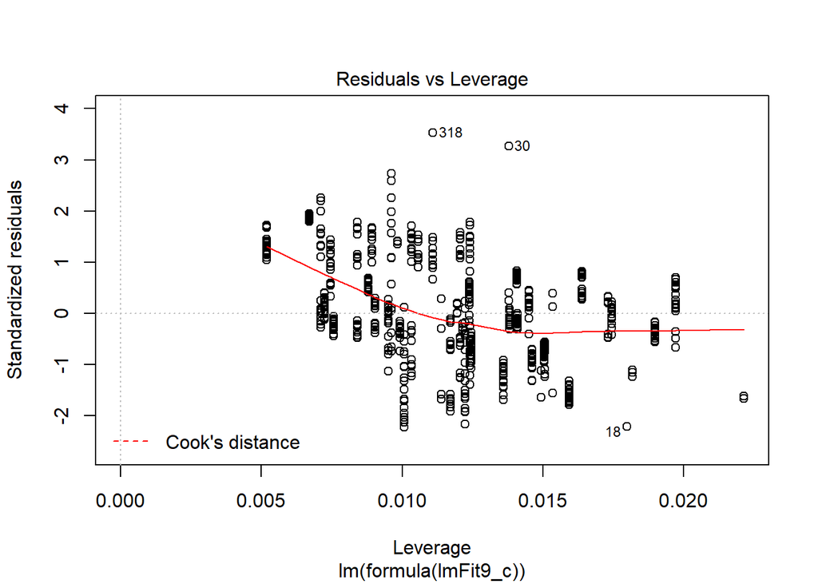

```r
plot(lmFit_c)
```

Of course it did, in fact, quite significantly. Multiple R squared and Adjusted R squared are close then the model is good

Task 2 : Predict the two response variables, Heating Load and Cooling Load, for the samples in assign1_EnergyPred.csv

Step 14 : Prediction on test dataset

14a : Loading test dataset

```r
testdata <- read.csv("C:/Users/Sanjusha/Desktop/CZ4073/Assignment1/assign1_EnergyPred.csv", header = TRUE)
```

14b : Predicting for HeatingLoad

```r
pred_h <- predict.lm(lmFit, testdata,interval='prediction',level=0.95)
pred_h[1:10]
```

```
##  [1] 12.793063 14.995273  8.588055 28.491947 40.071496 38.128779 33.544823
##  [8] 14.995273 11.095252 34.859840
```

```r
testdata_h <- testdata
testdata_h$HeatingLoad<-pred_h[1:10]
testdata_h
```

```
##    Compactness SurfaceArea WallArea RoofArea Height Orientation
## 1         0.69       735.0    294.0   220.50    3.5           2
## 2         0.66       759.5    318.5   220.50    3.5           4
## 3         0.74       686.0    245.0   220.50    3.5           2
## 4         0.98       514.5    294.0   110.25    7.0           2
## 5         0.76       661.5    416.5   122.50    7.0           3
## 6         0.76       661.5    416.5   122.50    7.0           3
## 7         0.79       637.0    343.0   147.00    7.0           5
## 8         0.66       759.5    318.5   220.50    3.5           5
## 9         0.66       759.5    318.5   220.50    3.5           5
## 10        0.90       563.5    318.5   122.50    7.0           3
##    GlazingArea GAreaDist HeatingLoad
## 1         0.10         3   12.793063
## 2         0.40         5   14.995273
## 3         0.10         1    8.588055
## 4         0.25         2   28.491947
## 5         0.40         5   40.071496
## 6         0.25         5   38.128779
## 7         0.25         2   33.544823
## 8         0.40         1   14.995273
## 9         0.10         1   11.095252
## 10        0.40         1   34.859840
```

14c : Predicting for CoolingLoad

```r
pred_c <- predict.lm(lmFit_c, testdata,interval='prediction',level=0.95)
pred_c[1:10]
```

```
##  [1] 16.00093 18.72016 11.91695 29.98871 39.28574 37.09208 34.02196
##  [8] 18.72016 14.33285 34.81195
```

```r
testdata_c <- testdata
testdata_c$CoolingLoad<-pred_c[1:10]
testdata_c
```

```
##    Compactness SurfaceArea WallArea RoofArea Height Orientation
## 1         0.69       735.0    294.0   220.50    3.5           2
## 2         0.66       759.5    318.5   220.50    3.5           4
## 3         0.74       686.0    245.0   220.50    3.5           2
## 4         0.98       514.5    294.0   110.25    7.0           2
## 5         0.76       661.5    416.5   122.50    7.0           3
## 6         0.76       661.5    416.5   122.50    7.0           3
## 7         0.79       637.0    343.0   147.00    7.0           5
## 8         0.66       759.5    318.5   220.50    3.5           5
## 9         0.66       759.5    318.5   220.50    3.5           5
## 10        0.90       563.5    318.5   122.50    7.0           3
##    GlazingArea GAreaDist CoolingLoad
## 1         0.10         3    16.00093
## 2         0.40         5    18.72016
## 3         0.10         1    11.91695
## 4         0.25         2    29.98871
## 5         0.40         5    39.28574
## 6         0.25         5    37.09208
## 7         0.25         2    34.02196
## 8         0.40         1    18.72016
## 9         0.10         1    14.33285
## 10        0.40         1    34.81195
```